# Udacity Project 3

# Wrangle and Analyze Data

- Introduction
- Data Gathering Data
- Data Assessing
- Data Cleaning
- Analyzing and Visualizing

# Introduction

Data wrangling is a core skill that everyone who works with data should be familiar with since so much of the world's data isn't clean. This project aims to to get insightful information about dog ratings from the twitter page WeRateDogs™, while demonstrating advanced data wrangling and visualization techniques using various Python libraries.

# Data Gathering

```python
#import all needed libraries
import pandas as pd
import requests
import tweepy as tp
import json
import numpy as np
import seaborn as sns
import matplotlib.pyplot as plt
sns.set()
```

### Reading a csv-file unsing Pandas and storing the data into DataFrame

```python
#reading twitter-archive-enhanced.csv into df1
df1 = pd.read_csv('twitter-archive-enhanced.csv')
df1.head()
```

|  | tweet_id | in_reply_to_status_id | in_reply_to_user_id | timestamp | source | text | retweeted_status_id | retweeted_status_user_id | retweeted_status_timestamp | expanded_urls | rating_numerator | rating_denominator | name | doggo | floofer | pupper | puppo |
| --- | --- | --- | --- | --- | --- | --- | --- | --- | --- | --- | --- | --- | --- | --- | --- | --- | --- |
| 0 | 892420643555336193 | NaN | NaN | 2017-08-01 16:23:56 +0000 | <a href="http://twitter.com/download/iphone" r... | This is Phineas. He's a mystical boy. Only eve... | NaN | NaN | NaN | https://twitter.com/dog_rates/status/892420643... | 13 | 10 | Phineas | None | None | None | None |
| 1 | 892177421306343426 | NaN | NaN | 2017-08-01 00:17:27 +0000 | <a href="http://twitter.com/download/iphone" r... | This is Tilly. She's just checking pup on you.... | NaN | NaN | NaN | https://twitter.com/dog_rates/status/892177421... | 13 | 10 | Tilly | None | None | None | None |
| 2 | 891815181378084864 | NaN | NaN | 2017-07-31 00:18:03 +0000 | <a href="http://twitter.com/download/iphone" r... | This is Archie. He is a rare Norwegian Pouncin... | NaN | NaN | NaN | https://twitter.com/dog_rates/status/891815181... | 12 | 10 | Archie | None | None | None | None |
| 3 | 891689557279858688 | NaN | NaN | 2017-07-30 15:58:51 +0000 | <a href="http://twitter.com/download/iphone" r... | This is Darla. She commenced a snooze mid meal... | NaN | NaN | NaN | https://twitter.com/dog_rates/status/891689557... | 13 | 10 | Darla | None | None | None | None |
| 4 | 891327558926688256 | NaN | NaN | 2017-07-29 16:00:24 +0000 | <a href="http://twitter.com/download/iphone" r... | This is Franklin. He would like you to stop ca... | NaN | NaN | NaN | https://twitter.com/dog_rates/status/891327558... | 12 | 10 | Franklin | None | None | None | None |

```python
# shappe of df1
df1.shape
```

```
(2356, 17)
```

```python
#creating a copy of df_archive to store an original version
df_archive = df1.copy()
```

### Downloading the tsv-file from intenten using request library and storing the data into DataFrame

```python
#download data from image-predictions.tsv
req_data = requests.get('https://d17h27t6h515a5.cloudfront.net/topher/2017/August/599fd2ad_image-predictions/image-predictions.tsv')
```

```python
#writing data to image-predictions.tsv
with open('image-predictions.tsv', mode='wb') as file:
    file.write(req_data.content)
```

```python
#storing data from image-predictions.tsv to df2
df2 = pd.read_csv('image-predictions.tsv', sep='\t')
df2.head()
```

|  | tweet_id | jpg_url | img_num | p1 | p1_conf | p1_dog | p2 | p2_conf | p2_dog | p3 | p3_conf | p3_dog |
| --- | --- | --- | --- | --- | --- | --- | --- | --- | --- | --- | --- | --- |
| 0 | 666020888022790149 | https://pbs.twimg.com/media/CT4udn0WwAA0aMy.jpg | 1 | Welsh_springer_spaniel | 0.465074 | True | collie | 0.156665 | True | Shetland_sheepdog | 0.061428 | True |
| 1 | 666029285002620928 | https://pbs.twimg.com/media/CT42GRgUYAA5iDo.jpg | 1 | redbone | 0.506826 | True | miniature_pinscher | 0.074192 | True | Rhodesian_ridgeback | 0.072010 | True |
| 2 | 666033412701032449 | https://pbs.twimg.com/media/CT4521TWwAEvMyu.jpg | 1 | German_shepherd | 0.596461 | True | malinois | 0.138584 | True | bloodhound | 0.116197 | True |
| 3 | 666044226329800704 | https://pbs.twimg.com/media/CT5Dr8HUEAA-lEu.jpg | 1 | Rhodesian_ridgeback | 0.408143 | True | redbone | 0.360687 | True | miniature_pinscher | 0.222752 | True |
| 4 | 666049248165822465 | https://pbs.twimg.com/media/CT5IQmsXIAAKY4A.jpg | 1 | miniature_pinscher | 0.560311 | True | Rottweiler | 0.243682 | True | Doberman | 0.154629 | True |

```python
# shappe of df1
df2.shape
```

```
(2075, 12)
```

```python
#creating a copy of df_image to store an original version
df_image = df2.copy()
```

### Query the Twitter API for tweets in the Twitter archive and save JSON in a text file

```python
#connecting to the twitter api
consumer_key = 'S42Hgv6BqUOQYzY47ZcCdO2gZ'
consumer_secret = 'RumHDN7i4LFKB1JKPmdkuMZnCzvLcfLjCyym0TcF0Ppsjz3lM7'
access_token = '989486218068090880-JGPGRJCSVpKZ5PLtKoRYL7VzMeB8wKL'
access_secret = '9rVfO5Keo46NNQAojGI9BJ5dtWsjznue1wVTeC8cuZVH1'

auth = tp.OAuthHandler(consumer_key, consumer_secret)
auth.set_access_token(access_token, access_secret)

api = tp.API(auth, wait_on_rate_limit = True, wait_on_rate_limit_notify = True)
```

```python
#obtaining a list of dictionaries from the twitter api
#with informations about each tweets id, favorite count, and retweet count

df_list = []
errors = []
for tweet_id in df_archive['tweet_id']:
    try:
        tweet = api.get_status(tweet_id, tweet_mode='extended')
        df_list.append({'tweet_id': str(tweet.id),
                        'favorite_count': int(tweet.favorite_count),
                        'retweet_count': int(tweet.retweet_count)})
    except Exception as e:
        print(str(tweet_id) + " : " + str(e))
        errors.append(tweet_id)
```

[output not shown]

```python
#saving obtained data into a file
with open('tweet_json.txt', 'w') as outfile:
    json.dump(df_list, outfile)
```

```python
#reading data from file into df3
with open('tweet_json.txt', 'r') as file:
    df3 = pd.DataFrame(json.load(file), columns=['tweet_id', 'favorite_count', 'retweet_count'])
```

```python
# quick look at df3
df3.head()
```

|  | tweet_id | favorite_count | retweet_count |
| --- | --- | --- | --- |
| 0 | 892420643555336193 | 36291 | 7724 |
| 1 | 892177421306343426 | 31298 | 5717 |
| 2 | 891815181378084864 | 23568 | 3786 |
| 3 | 891689557279858688 | 39595 | 7885 |
| 4 | 891327558926688256 | 37807 | 8506 |

```python
df3.shape
```

```
(2331, 3)
```

```python
#creating a copy of df_tweet to store an original version
df_tweet = df3.copy()
```

### Gathering Data Summary

Gathering the data was the first step in the data wrangling process. Ath this point the high level gathering process was finished.  
As result three DataFrames were obtained:

1. DataFrame from an existing csv-file (twitter-archive-enhanced.csv) using pandas
2. DataFrame from tsv-file downloaded from the internet (image-predictions.tsv) using requests
3. Querying an API (tweet_json.txt) obtaining JSON object of all the tweet_ids using tweepy

Obtained data was imported into programming environment

# Data Assesing

Assessing the data is the second step in data wrangling. We are going to inspect the dataset for data quality issues (i.e. content issues) and lack of tidiness (i.e. structural issues).

We will assess data for:

1. Quality: issues with content. Low quality data is also known as dirty data.
2. Tidiness: issues with structure that prevent easy analysis. Untidy data is also known as messy data.

Tidy data requirements:

1. Each variable forms a column.
2. Each observation forms a row.
3. Each type of observational unit forms a table.

### Visual assessment

```python
df_archive
```

|  | tweet_id | in_reply_to_status_id | in_reply_to_user_id | timestamp | source | text | retweeted_status_id | retweeted_status_user_id | retweeted_status_timestamp | expanded_urls | rating_numerator | rating_denominator | name | doggo | floofer | pupper | puppo |
| --- | --- | --- | --- | --- | --- | --- | --- | --- | --- | --- | --- | --- | --- | --- | --- | --- | --- |
| 0 | 892420643555336193 | NaN | NaN | 2017-08-01 16:23:56 +0000 | <a href="http://twitter.com/download/iphone" r... | This is Phineas. He's a mystical boy. Only eve... | NaN | NaN | NaN | https://twitter.com/dog_rates/status/892420643... | 13 | 10 | Phineas | None | None | None | None |
| 1 | 892177421306343426 | NaN | NaN | 2017-08-01 00:17:27 +0000 | <a href="http://twitter.com/download/iphone" r... | This is Tilly. She's just checking pup on you.... | NaN | NaN | NaN | https://twitter.com/dog_rates/status/892177421... | 13 | 10 | Tilly | None | None | None | None |
| 2 | 891815181378084864 | NaN | NaN | 2017-07-31 00:18:03 +0000 | <a href="http://twitter.com/download/iphone" r... | This is Archie. He is a rare Norwegian Pouncin... | NaN | NaN | NaN | https://twitter.com/dog_rates/status/891815181... | 12 | 10 | Archie | None | None | None | None |
| 3 | 891689557279858688 | NaN | NaN | 2017-07-30 15:58:51 +0000 | <a href="http://twitter.com/download/iphone" r... | This is Darla. She commenced a snooze mid meal... | NaN | NaN | NaN | https://twitter.com/dog_rates/status/891689557... | 13 | 10 | Darla | None | None | None | None |
| 4 | 891327558926688256 | NaN | NaN | 2017-07-29 16:00:24 +0000 | <a href="http://twitter.com/download/iphone" r... | This is Franklin. He would like you to stop ca... | NaN | NaN | NaN | https://twitter.com/dog_rates/status/891327558... | 12 | 10 | Franklin | None | None | None | None |
| 5 | 891087950875897856 | NaN | NaN | 2017-07-29 00:08:17 +0000 | <a href="http://twitter.com/download/iphone" r... | Here we have a majestic great white breaching ... | NaN | NaN | NaN | https://twitter.com/dog_rates/status/891087950... | 13 | 10 | None | None | None | None | None |
| 6 | 890971913173991426 | NaN | NaN | 2017-07-28 16:27:12 +0000 | <a href="http://twitter.com/download/iphone" r... | Meet Jax. He enjoys ice cream so much he gets ... | NaN | NaN | NaN | https://gofundme.com/ydvmve-surgery-for-jax,ht... | 13 | 10 | Jax | None | None | None | None |
| 7 | 890729181411237888 | NaN | NaN | 2017-07-28 00:22:40 +0000 | <a href="http://twitter.com/download/iphone" r... | When you watch your owner call another dog a g... | NaN | NaN | NaN | https://twitter.com/dog_rates/status/890729181... | 13 | 10 | None | None | None | None | None |
| 8 | 890609185150312448 | NaN | NaN | 2017-07-27 16:25:51 +0000 | <a href="http://twitter.com/download/iphone" r... | This is Zoey. She doesn't want to be one of th... | NaN | NaN | NaN | https://twitter.com/dog_rates/status/890609185... | 13 | 10 | Zoey | None | None | None | None |
| 9 | 890240255349198849 | NaN | NaN | 2017-07-26 15:59:51 +0000 | <a href="http://twitter.com/download/iphone" r... | This is Cassie. She is a college pup. Studying... | NaN | NaN | NaN | https://twitter.com/dog_rates/status/890240255... | 14 | 10 | Cassie | doggo | None | None | None |
| 10 | 890006608113172480 | NaN | NaN | 2017-07-26 00:31:25 +0000 | <a href="http://twitter.com/download/iphone" r... | This is Koda. He is a South Australian decksha... | NaN | NaN | NaN | https://twitter.com/dog_rates/status/890006608... | 13 | 10 | Koda | None | None | None | None |
| 11 | 889880896479866881 | NaN | NaN | 2017-07-25 16:11:53 +0000 | <a href="http://twitter.com/download/iphone" r... | This is Bruno. He is a service shark. Only get... | NaN | NaN | NaN | https://twitter.com/dog_rates/status/889880896... | 13 | 10 | Bruno | None | None | None | None |
| 12 | 889665388333682689 | NaN | NaN | 2017-07-25 01:55:32 +0000 | <a href="http://twitter.com/download/iphone" r... | Here's a puppo that seems to be on the fence a... | NaN | NaN | NaN | https://twitter.com/dog_rates/status/889665388... | 13 | 10 | None | None | None | None | puppo |
| 13 | 889638837579907072 | NaN | NaN | 2017-07-25 00:10:02 +0000 | <a href="http://twitter.com/download/iphone" r... | This is Ted. He does his best. Sometimes that'... | NaN | NaN | NaN | https://twitter.com/dog_rates/status/889638837... | 12 | 10 | Ted | None | None | None | None |
| 14 | 889531135344209921 | NaN | NaN | 2017-07-24 17:02:04 +0000 | <a href="http://twitter.com/download/iphone" r... | This is Stuart. He's sporting his favorite fan... | NaN | NaN | NaN | https://twitter.com/dog_rates/status/889531135... | 13 | 10 | Stuart | None | None | None | puppo |
| 15 | 889278841981685760 | NaN | NaN | 2017-07-24 00:19:32 +0000 | <a href="http://twitter.com/download/iphone" r... | This is Oliver. You're witnessing one of his m... | NaN | NaN | NaN | https://twitter.com/dog_rates/status/889278841... | 13 | 10 | Oliver | None | None | None | None |
| 16 | 888917238123831296 | NaN | NaN | 2017-07-23 00:22:39 +0000 | <a href="http://twitter.com/download/iphone" r... | This is Jim. He found a fren. Taught him how t... | NaN | NaN | NaN | https://twitter.com/dog_rates/status/888917238... | 12 | 10 | Jim | None | None | None | None |
| 17 | 888804989199671297 | NaN | NaN | 2017-07-22 16:56:37 +0000 | <a href="http://twitter.com/download/iphone" r... | This is Zeke. He has a new stick. Very proud o... | NaN | NaN | NaN | https://twitter.com/dog_rates/status/888804989... | 13 | 10 | Zeke | None | None | None | None |
| 18 | 888554962724278272 | NaN | NaN | 2017-07-22 00:23:06 +0000 | <a href="http://twitter.com/download/iphone" r... | This is Ralphus. He's powering up. Attempting ... | NaN | NaN | NaN | https://twitter.com/dog_rates/status/888554962... | 13 | 10 | Ralphus | None | None | None | None |
| 19 | 888202515573088257 | NaN | NaN | 2017-07-21 01:02:36 +0000 | <a href="http://twitter.com/download/iphone" r... | RT @dog_rates: This is Canela. She attempted s... | 8.874740e+17 | 4.196984e+09 | 2017-07-19 00:47:34 +0000 | https://twitter.com/dog_rates/status/887473957... | 13 | 10 | Canela | None | None | None | None |
| 20 | 888078434458587136 | NaN | NaN | 2017-07-20 16:49:33 +0000 | <a href="http://twitter.com/download/iphone" r... | This is Gerald. He was just told he didn't get... | NaN | NaN | NaN | https://twitter.com/dog_rates/status/888078434... | 12 | 10 | Gerald | None | None | None | None |
| 21 | 887705289381826560 | NaN | NaN | 2017-07-19 16:06:48 +0000 | <a href="http://twitter.com/download/iphone" r... | This is Jeffrey. He has a monopoly on the pool... | NaN | NaN | NaN | https://twitter.com/dog_rates/status/887705289... | 13 | 10 | Jeffrey | None | None | None | None |
| 22 | 887517139158093824 | NaN | NaN | 2017-07-19 03:39:09 +0000 | <a href="http://twitter.com/download/iphone" r... | I've yet to rate a Venezuelan Hover Wiener. Th... | NaN | NaN | NaN | https://twitter.com/dog_rates/status/887517139... | 14 | 10 | such | None | None | None | None |
| 23 | 887473957103951883 | NaN | NaN | 2017-07-19 00:47:34 +0000 | <a href="http://twitter.com/download/iphone" r... | This is Canela. She attempted some fancy porch... | NaN | NaN | NaN | https://twitter.com/dog_rates/status/887473957... | 13 | 10 | Canela | None | None | None | None |
| 24 | 887343217045368832 | NaN | NaN | 2017-07-18 16:08:03 +0000 | <a href="http://twitter.com/download/iphone" r... | You may not have known you needed to see this ... | NaN | NaN | NaN | https://twitter.com/dog_rates/status/887343217... | 13 | 10 | None | None | None | None | None |
| 25 | 887101392804085760 | NaN | NaN | 2017-07-18 00:07:08 +0000 | <a href="http://twitter.com/download/iphone" r... | This... is a Jubilant Antarctic House Bear. We... | NaN | NaN | NaN | https://twitter.com/dog_rates/status/887101392... | 12 | 10 | None | None | None | None | None |
| 26 | 886983233522544640 | NaN | NaN | 2017-07-17 16:17:36 +0000 | <a href="http://twitter.com/download/iphone" r... | This is Maya. She's very shy. Rarely leaves he... | NaN | NaN | NaN | https://twitter.com/dog_rates/status/886983233... | 13 | 10 | Maya | None | None | None | None |
| 27 | 886736880519319552 | NaN | NaN | 2017-07-16 23:58:41 +0000 | <a href="http://twitter.com/download/iphone" r... | This is Mingus. He's a wonderful father to his... | NaN | NaN | NaN | https://www.gofundme.com/mingusneedsus,https:/... | 13 | 10 | Mingus | None | None | None | None |
| 28 | 886680336477933568 | NaN | NaN | 2017-07-16 20:14:00 +0000 | <a href="http://twitter.com/download/iphone" r... | This is Derek. He's late for a dog meeting. 13... | NaN | NaN | NaN | https://twitter.com/dog_rates/status/886680336... | 13 | 10 | Derek | None | None | None | None |
| 29 | 886366144734445568 | NaN | NaN | 2017-07-15 23:25:31 +0000 | <a href="http://twitter.com/download/iphone" r... | This is Roscoe. Another pupper fallen victim t... | NaN | NaN | NaN | https://twitter.com/dog_rates/status/886366144... | 12 | 10 | Roscoe | None | None | pupper | None |
| ... | ... | ... | ... | ... | ... | ... | ... | ... | ... | ... | ... | ... | ... | ... | ... | ... | ... |
| 2326 | 666411507551481857 | NaN | NaN | 2015-11-17 00:24:19 +0000 | <a href="http://twitter.com/download/iphone" r... | This is quite the dog. Gets really excited whe... | NaN | NaN | NaN | https://twitter.com/dog_rates/status/666411507... | 2 | 10 | quite | None | None | None | None |
| 2327 | 666407126856765440 | NaN | NaN | 2015-11-17 00:06:54 +0000 | <a href="http://twitter.com/download/iphone" r... | This is a southern Vesuvius bumblegruff. Can d... | NaN | NaN | NaN | https://twitter.com/dog_rates/status/666407126... | 7 | 10 | a | None | None | None | None |
| 2328 | 666396247373291520 | NaN | NaN | 2015-11-16 23:23:41 +0000 | <a href="http://twitter.com/download/iphone" r... | Oh goodness. A super rare northeast Qdoba kang... | NaN | NaN | NaN | https://twitter.com/dog_rates/status/666396247... | 9 | 10 | None | None | None | None | None |
| 2329 | 666373753744588802 | NaN | NaN | 2015-11-16 21:54:18 +0000 | <a href="http://twitter.com/download/iphone" r... | Those are sunglasses and a jean jacket. 11/10 ... | NaN | NaN | NaN | https://twitter.com/dog_rates/status/666373753... | 11 | 10 | None | None | None | None | None |
| 2330 | 666362758909284353 | NaN | NaN | 2015-11-16 21:10:36 +0000 | <a href="http://twitter.com/download/iphone" r... | Unique dog here. Very small. Lives in containe... | NaN | NaN | NaN | https://twitter.com/dog_rates/status/666362758... | 6 | 10 | None | None | None | None | None |
| 2331 | 666353288456101888 | NaN | NaN | 2015-11-16 20:32:58 +0000 | <a href="http://twitter.com/download/iphone" r... | Here we have a mixed Asiago from the Galápagos... | NaN | NaN | NaN | https://twitter.com/dog_rates/status/666353288... | 8 | 10 | None | None | None | None | None |
| 2332 | 666345417576210432 | NaN | NaN | 2015-11-16 20:01:42 +0000 | <a href="http://twitter.com/download/iphone" r... | Look at this jokester thinking seat belt laws ... | NaN | NaN | NaN | https://twitter.com/dog_rates/status/666345417... | 10 | 10 | None | None | None | None | None |
| 2333 | 666337882303524864 | NaN | NaN | 2015-11-16 19:31:45 +0000 | <a href="http://twitter.com/download/iphone" r... | This is an extremely rare horned Parthenon. No... | NaN | NaN | NaN | https://twitter.com/dog_rates/status/666337882... | 9 | 10 | an | None | None | None | None |
| 2334 | 666293911632134144 | NaN | NaN | 2015-11-16 16:37:02 +0000 | <a href="http://twitter.com/download/iphone" r... | This is a funny dog. Weird toes. Won't come do... | NaN | NaN | NaN | https://twitter.com/dog_rates/status/666293911... | 3 | 10 | a | None | None | None | None |
| 2335 | 666287406224695296 | NaN | NaN | 2015-11-16 16:11:11 +0000 | <a href="http://twitter.com/download/iphone" r... | This is an Albanian 3 1/2 legged Episcopalian... | NaN | NaN | NaN | https://twitter.com/dog_rates/status/666287406... | 1 | 2 | an | None | None | None | None |
| 2336 | 666273097616637952 | NaN | NaN | 2015-11-16 15:14:19 +0000 | <a href="http://twitter.com/download/iphone" r... | Can take selfies 11/10 https://t.co/ws2AMaNwPW | NaN | NaN | NaN | https://twitter.com/dog_rates/status/666273097... | 11 | 10 | None | None | None | None | None |
| 2337 | 666268910803644416 | NaN | NaN | 2015-11-16 14:57:41 +0000 | <a href="http://twitter.com/download/iphone" r... | Very concerned about fellow dog trapped in com... | NaN | NaN | NaN | https://twitter.com/dog_rates/status/666268910... | 10 | 10 | None | None | None | None | None |
| 2338 | 666104133288665088 | NaN | NaN | 2015-11-16 04:02:55 +0000 | <a href="http://twitter.com/download/iphone" r... | Not familiar with this breed. No tail (weird).... | NaN | NaN | NaN | https://twitter.com/dog_rates/status/666104133... | 1 | 10 | None | None | None | None | None |
| 2339 | 666102155909144576 | NaN | NaN | 2015-11-16 03:55:04 +0000 | <a href="http://twitter.com/download/iphone" r... | Oh my. Here you are seeing an Adobe Setter giv... | NaN | NaN | NaN | https://twitter.com/dog_rates/status/666102155... | 11 | 10 | None | None | None | None | None |
| 2340 | 666099513787052032 | NaN | NaN | 2015-11-16 03:44:34 +0000 | <a href="http://twitter.com/download/iphone" r... | Can stand on stump for what seems like a while... | NaN | NaN | NaN | https://twitter.com/dog_rates/status/666099513... | 8 | 10 | None | None | None | None | None |
| 2341 | 666094000022159362 | NaN | NaN | 2015-11-16 03:22:39 +0000 | <a href="http://twitter.com/download/iphone" r... | This appears to be a Mongolian Presbyterian mi... | NaN | NaN | NaN | https://twitter.com/dog_rates/status/666094000... | 9 | 10 | None | None | None | None | None |
| 2342 | 666082916733198337 | NaN | NaN | 2015-11-16 02:38:37 +0000 | <a href="http://twitter.com/download/iphone" r... | Here we have a well-established sunblockerspan... | NaN | NaN | NaN | https://twitter.com/dog_rates/status/666082916... | 6 | 10 | None | None | None | None | None |
| 2343 | 666073100786774016 | NaN | NaN | 2015-11-16 01:59:36 +0000 | <a href="http://twitter.com/download/iphone" r... | Let's hope this flight isn't Malaysian (lol). ... | NaN | NaN | NaN | https://twitter.com/dog_rates/status/666073100... | 10 | 10 | None | None | None | None | None |
| 2344 | 666071193221509120 | NaN | NaN | 2015-11-16 01:52:02 +0000 | <a href="http://twitter.com/download/iphone" r... | Here we have a northern speckled Rhododendron.... | NaN | NaN | NaN | https://twitter.com/dog_rates/status/666071193... | 9 | 10 | None | None | None | None | None |
| 2345 | 666063827256086533 | NaN | NaN | 2015-11-16 01:22:45 +0000 | <a href="http://twitter.com/download/iphone" r... | This is the happiest dog you will ever see. Ve... | NaN | NaN | NaN | https://twitter.com/dog_rates/status/666063827... | 10 | 10 | the | None | None | None | None |
| 2346 | 666058600524156928 | NaN | NaN | 2015-11-16 01:01:59 +0000 | <a href="http://twitter.com/download/iphone" r... | Here is the Rand Paul of retrievers folks! He'... | NaN | NaN | NaN | https://twitter.com/dog_rates/status/666058600... | 8 | 10 | the | None | None | None | None |
| 2347 | 666057090499244032 | NaN | NaN | 2015-11-16 00:55:59 +0000 | <a href="http://twitter.com/download/iphone" r... | My oh my. This is a rare blond Canadian terrie... | NaN | NaN | NaN | https://twitter.com/dog_rates/status/666057090... | 9 | 10 | a | None | None | None | None |
| 2348 | 666055525042405380 | NaN | NaN | 2015-11-16 00:49:46 +0000 | <a href="http://twitter.com/download/iphone" r... | Here is a Siberian heavily armored polar bear ... | NaN | NaN | NaN | https://twitter.com/dog_rates/status/666055525... | 10 | 10 | a | None | None | None | None |
| 2349 | 666051853826850816 | NaN | NaN | 2015-11-16 00:35:11 +0000 | <a href="http://twitter.com/download/iphone" r... | This is an odd dog. Hard on the outside but lo... | NaN | NaN | NaN | https://twitter.com/dog_rates/status/666051853... | 2 | 10 | an | None | None | None | None |
| 2350 | 666050758794694657 | NaN | NaN | 2015-11-16 00:30:50 +0000 | <a href="http://twitter.com/download/iphone" r... | This is a truly beautiful English Wilson Staff... | NaN | NaN | NaN | https://twitter.com/dog_rates/status/666050758... | 10 | 10 | a | None | None | None | None |
| 2351 | 666049248165822465 | NaN | NaN | 2015-11-16 00:24:50 +0000 | <a href="http://twitter.com/download/iphone" r... | Here we have a 1949 1st generation vulpix. Enj... | NaN | NaN | NaN | https://twitter.com/dog_rates/status/666049248... | 5 | 10 | None | None | None | None | None |
| 2352 | 666044226329800704 | NaN | NaN | 2015-11-16 00:04:52 +0000 | <a href="http://twitter.com/download/iphone" r... | This is a purebred Piers Morgan. Loves to Netf... | NaN | NaN | NaN | https://twitter.com/dog_rates/status/666044226... | 6 | 10 | a | None | None | None | None |
| 2353 | 666033412701032449 | NaN | NaN | 2015-11-15 23:21:54 +0000 | <a href="http://twitter.com/download/iphone" r... | Here is a very happy pup. Big fan of well-main... | NaN | NaN | NaN | https://twitter.com/dog_rates/status/666033412... | 9 | 10 | a | None | None | None | None |
| 2354 | 666029285002620928 | NaN | NaN | 2015-11-15 23:05:30 +0000 | <a href="http://twitter.com/download/iphone" r... | This is a western brown Mitsubishi terrier. Up... | NaN | NaN | NaN | https://twitter.com/dog_rates/status/666029285... | 7 | 10 | a | None | None | None | None |
| 2355 | 666020888022790149 | NaN | NaN | 2015-11-15 22:32:08 +0000 | <a href="http://twitter.com/download/iphone" r... | Here we have a Japanese Irish Setter. Lost eye... | NaN | NaN | NaN | https://twitter.com/dog_rates/status/666020888... | 8 | 10 | None | None | None | None | None |

2356 rows × 17 columns

```python
df_image
```

|  | tweet_id | jpg_url | img_num | p1 | p1_conf | p1_dog | p2 | p2_conf | p2_dog | p3 | p3_conf | p3_dog |
| --- | --- | --- | --- | --- | --- | --- | --- | --- | --- | --- | --- | --- |
| 0 | 666020888022790149 | https://pbs.twimg.com/media/CT4udn0WwAA0aMy.jpg | 1 | Welsh_springer_spaniel | 0.465074 | True | collie | 0.156665 | True | Shetland_sheepdog | 0.061428 | True |
| 1 | 666029285002620928 | https://pbs.twimg.com/media/CT42GRgUYAA5iDo.jpg | 1 | redbone | 0.506826 | True | miniature_pinscher | 0.074192 | True | Rhodesian_ridgeback | 0.072010 | True |
| 2 | 666033412701032449 | https://pbs.twimg.com/media/CT4521TWwAEvMyu.jpg | 1 | German_shepherd | 0.596461 | True | malinois | 0.138584 | True | bloodhound | 0.116197 | True |
| 3 | 666044226329800704 | https://pbs.twimg.com/media/CT5Dr8HUEAA-lEu.jpg | 1 | Rhodesian_ridgeback | 0.408143 | True | redbone | 0.360687 | True | miniature_pinscher | 0.222752 | True |
| 4 | 666049248165822465 | https://pbs.twimg.com/media/CT5IQmsXIAAKY4A.jpg | 1 | miniature_pinscher | 0.560311 | True | Rottweiler | 0.243682 | True | Doberman | 0.154629 | True |
| 5 | 666050758794694657 | https://pbs.twimg.com/media/CT5Jof1WUAEuVxN.jpg | 1 | Bernese_mountain_dog | 0.651137 | True | English_springer | 0.263788 | True | Greater_Swiss_Mountain_dog | 0.016199 | True |
| 6 | 666051853826850816 | https://pbs.twimg.com/media/CT5KoJ1WoAAJash.jpg | 1 | box_turtle | 0.933012 | False | mud_turtle | 0.045885 | False | terrapin | 0.017885 | False |
| 7 | 666055525042405380 | https://pbs.twimg.com/media/CT5N9tpXIAAifs1.jpg | 1 | chow | 0.692517 | True | Tibetan_mastiff | 0.058279 | True | fur_coat | 0.054449 | False |
| 8 | 666057090499244032 | https://pbs.twimg.com/media/CT5PY90WoAAQGLo.jpg | 1 | shopping_cart | 0.962465 | False | shopping_basket | 0.014594 | False | golden_retriever | 0.007959 | True |
| 9 | 666058600524156928 | https://pbs.twimg.com/media/CT5Qw94XAAA_2dP.jpg | 1 | miniature_poodle | 0.201493 | True | komondor | 0.192305 | True | soft-coated_wheaten_terrier | 0.082086 | True |
| 10 | 666063827256086533 | https://pbs.twimg.com/media/CT5Vg_wXIAAXfnj.jpg | 1 | golden_retriever | 0.775930 | True | Tibetan_mastiff | 0.093718 | True | Labrador_retriever | 0.072427 | True |
| 11 | 666071193221509120 | https://pbs.twimg.com/media/CT5cN_3WEAAlOoZ.jpg | 1 | Gordon_setter | 0.503672 | True | Yorkshire_terrier | 0.174201 | True | Pekinese | 0.109454 | True |
| 12 | 666073100786774016 | https://pbs.twimg.com/media/CT5d9DZXAAALcwe.jpg | 1 | Walker_hound | 0.260857 | True | English_foxhound | 0.175382 | True | Ibizan_hound | 0.097471 | True |
| 13 | 666082916733198337 | https://pbs.twimg.com/media/CT5m4VGWEAAtKc8.jpg | 1 | pug | 0.489814 | True | bull_mastiff | 0.404722 | True | French_bulldog | 0.048960 | True |
| 14 | 666094000022159362 | https://pbs.twimg.com/media/CT5w9gUW4AAsBNN.jpg | 1 | bloodhound | 0.195217 | True | German_shepherd | 0.078260 | True | malinois | 0.075628 | True |
| 15 | 666099513787052032 | https://pbs.twimg.com/media/CT51-JJUEAA6hV8.jpg | 1 | Lhasa | 0.582330 | True | Shih-Tzu | 0.166192 | True | Dandie_Dinmont | 0.089688 | True |
| 16 | 666102155909144576 | https://pbs.twimg.com/media/CT54YGiWUAEZnoK.jpg | 1 | English_setter | 0.298617 | True | Newfoundland | 0.149842 | True | borzoi | 0.133649 | True |
| 17 | 666104133288665088 | https://pbs.twimg.com/media/CT56LSZWoAAlJj2.jpg | 1 | hen | 0.965932 | False | cock | 0.033919 | False | partridge | 0.000052 | False |
| 18 | 666268910803644416 | https://pbs.twimg.com/media/CT8QCd1WEAADXws.jpg | 1 | desktop_computer | 0.086502 | False | desk | 0.085547 | False | bookcase | 0.079480 | False |
| 19 | 666273097616637952 | https://pbs.twimg.com/media/CT8T1mtUwAA3aqm.jpg | 1 | Italian_greyhound | 0.176053 | True | toy_terrier | 0.111884 | True | basenji | 0.111152 | True |
| 20 | 666287406224695296 | https://pbs.twimg.com/media/CT8g3BpUEAAuFjg.jpg | 1 | Maltese_dog | 0.857531 | True | toy_poodle | 0.063064 | True | miniature_poodle | 0.025581 | True |
| 21 | 666293911632134144 | https://pbs.twimg.com/media/CT8mx7KW4AEQu8N.jpg | 1 | three-toed_sloth | 0.914671 | False | otter | 0.015250 | False | great_grey_owl | 0.013207 | False |
| 22 | 666337882303524864 | https://pbs.twimg.com/media/CT9OwFIWEAMuRje.jpg | 1 | ox | 0.416669 | False | Newfoundland | 0.278407 | True | groenendael | 0.102643 | True |
| 23 | 666345417576210432 | https://pbs.twimg.com/media/CT9Vn7PWoAA_ZCM.jpg | 1 | golden_retriever | 0.858744 | True | Chesapeake_Bay_retriever | 0.054787 | True | Labrador_retriever | 0.014241 | True |
| 24 | 666353288456101888 | https://pbs.twimg.com/media/CT9cx0tUEAAhNN_.jpg | 1 | malamute | 0.336874 | True | Siberian_husky | 0.147655 | True | Eskimo_dog | 0.093412 | True |
| 25 | 666362758909284353 | https://pbs.twimg.com/media/CT9lXGsUcAAyUFt.jpg | 1 | guinea_pig | 0.996496 | False | skunk | 0.002402 | False | hamster | 0.000461 | False |
| 26 | 666373753744588802 | https://pbs.twimg.com/media/CT9vZEYWUAAlZ05.jpg | 1 | soft-coated_wheaten_terrier | 0.326467 | True | Afghan_hound | 0.259551 | True | briard | 0.206803 | True |
| 27 | 666396247373291520 | https://pbs.twimg.com/media/CT-D2ZHWIAA3gK1.jpg | 1 | Chihuahua | 0.978108 | True | toy_terrier | 0.009397 | True | papillon | 0.004577 | True |
| 28 | 666407126856765440 | https://pbs.twimg.com/media/CT-NvwmW4AAugGZ.jpg | 1 | black-and-tan_coonhound | 0.529139 | True | bloodhound | 0.244220 | True | flat-coated_retriever | 0.173810 | True |
| 29 | 666411507551481857 | https://pbs.twimg.com/media/CT-RugiWIAELEaq.jpg | 1 | coho | 0.404640 | False | barracouta | 0.271485 | False | gar | 0.189945 | False |
| ... | ... | ... | ... | ... | ... | ... | ... | ... | ... | ... | ... | ... |
| 2045 | 886366144734445568 | https://pbs.twimg.com/media/DE0BTnQUwAApKEH.jpg | 1 | French_bulldog | 0.999201 | True | Chihuahua | 0.000361 | True | Boston_bull | 0.000076 | True |
| 2046 | 886680336477933568 | https://pbs.twimg.com/media/DE4fEDzWAAAyHMM.jpg | 1 | convertible | 0.738995 | False | sports_car | 0.139952 | False | car_wheel | 0.044173 | False |
| 2047 | 886736880519319552 | https://pbs.twimg.com/media/DE5Se8FXcAAJFx4.jpg | 1 | kuvasz | 0.309706 | True | Great_Pyrenees | 0.186136 | True | Dandie_Dinmont | 0.086346 | True |
| 2048 | 886983233522544640 | https://pbs.twimg.com/media/DE8yicJW0AAAvBJ.jpg | 2 | Chihuahua | 0.793469 | True | toy_terrier | 0.143528 | True | can_opener | 0.032253 | False |
| 2049 | 887101392804085760 | https://pbs.twimg.com/media/DE-eAq6UwAA-jaE.jpg | 1 | Samoyed | 0.733942 | True | Eskimo_dog | 0.035029 | True | Staffordshire_bullterrier | 0.029705 | True |
| 2050 | 887343217045368832 | https://pbs.twimg.com/ext_tw_video_thumb/88734... | 1 | Mexican_hairless | 0.330741 | True | sea_lion | 0.275645 | False | Weimaraner | 0.134203 | True |
| 2051 | 887473957103951883 | https://pbs.twimg.com/media/DFDw2tyUQAAAFke.jpg | 2 | Pembroke | 0.809197 | True | Rhodesian_ridgeback | 0.054950 | True | beagle | 0.038915 | True |
| 2052 | 887517139158093824 | https://pbs.twimg.com/ext_tw_video_thumb/88751... | 1 | limousine | 0.130432 | False | tow_truck | 0.029175 | False | shopping_cart | 0.026321 | False |
| 2053 | 887705289381826560 | https://pbs.twimg.com/media/DFHDQBbXgAEqY7t.jpg | 1 | basset | 0.821664 | True | redbone | 0.087582 | True | Weimaraner | 0.026236 | True |
| 2054 | 888078434458587136 | https://pbs.twimg.com/media/DFMWn56WsAAkA7B.jpg | 1 | French_bulldog | 0.995026 | True | pug | 0.000932 | True | bull_mastiff | 0.000903 | True |
| 2055 | 888202515573088257 | https://pbs.twimg.com/media/DFDw2tyUQAAAFke.jpg | 2 | Pembroke | 0.809197 | True | Rhodesian_ridgeback | 0.054950 | True | beagle | 0.038915 | True |
| 2056 | 888554962724278272 | https://pbs.twimg.com/media/DFTH_O-UQAACu20.jpg | 3 | Siberian_husky | 0.700377 | True | Eskimo_dog | 0.166511 | True | malamute | 0.111411 | True |
| 2057 | 888804989199671297 | https://pbs.twimg.com/media/DFWra-3VYAA2piG.jpg | 1 | golden_retriever | 0.469760 | True | Labrador_retriever | 0.184172 | True | English_setter | 0.073482 | True |
| 2058 | 888917238123831296 | https://pbs.twimg.com/media/DFYRgsOUQAARGhO.jpg | 1 | golden_retriever | 0.714719 | True | Tibetan_mastiff | 0.120184 | True | Labrador_retriever | 0.105506 | True |
| 2059 | 889278841981685760 | https://pbs.twimg.com/ext_tw_video_thumb/88927... | 1 | whippet | 0.626152 | True | borzoi | 0.194742 | True | Saluki | 0.027351 | True |
| 2060 | 889531135344209921 | https://pbs.twimg.com/media/DFg_2PVW0AEHN3p.jpg | 1 | golden_retriever | 0.953442 | True | Labrador_retriever | 0.013834 | True | redbone | 0.007958 | True |
| 2061 | 889638837579907072 | https://pbs.twimg.com/media/DFihzFfXsAYGDPR.jpg | 1 | French_bulldog | 0.991650 | True | boxer | 0.002129 | True | Staffordshire_bullterrier | 0.001498 | True |
| 2062 | 889665388333682689 | https://pbs.twimg.com/media/DFi579UWsAAatzw.jpg | 1 | Pembroke | 0.966327 | True | Cardigan | 0.027356 | True | basenji | 0.004633 | True |
| 2063 | 889880896479866881 | https://pbs.twimg.com/media/DFl99B1WsAITKsg.jpg | 1 | French_bulldog | 0.377417 | True | Labrador_retriever | 0.151317 | True | muzzle | 0.082981 | False |
| 2064 | 890006608113172480 | https://pbs.twimg.com/media/DFnwSY4WAAAMliS.jpg | 1 | Samoyed | 0.957979 | True | Pomeranian | 0.013884 | True | chow | 0.008167 | True |
| 2065 | 890240255349198849 | https://pbs.twimg.com/media/DFrEyVuW0AAO3t9.jpg | 1 | Pembroke | 0.511319 | True | Cardigan | 0.451038 | True | Chihuahua | 0.029248 | True |
| 2066 | 890609185150312448 | https://pbs.twimg.com/media/DFwUU__XcAEpyXI.jpg | 1 | Irish_terrier | 0.487574 | True | Irish_setter | 0.193054 | True | Chesapeake_Bay_retriever | 0.118184 | True |
| 2067 | 890729181411237888 | https://pbs.twimg.com/media/DFyBahAVwAAhUTd.jpg | 2 | Pomeranian | 0.566142 | True | Eskimo_dog | 0.178406 | True | Pembroke | 0.076507 | True |
| 2068 | 890971913173991426 | https://pbs.twimg.com/media/DF1eOmZXUAALUcq.jpg | 1 | Appenzeller | 0.341703 | True | Border_collie | 0.199287 | True | ice_lolly | 0.193548 | False |
| 2069 | 891087950875897856 | https://pbs.twimg.com/media/DF3HwyEWsAABqE6.jpg | 1 | Chesapeake_Bay_retriever | 0.425595 | True | Irish_terrier | 0.116317 | True | Indian_elephant | 0.076902 | False |
| 2070 | 891327558926688256 | https://pbs.twimg.com/media/DF6hr6BUMAAzZgT.jpg | 2 | basset | 0.555712 | True | English_springer | 0.225770 | True | German_short-haired_pointer | 0.175219 | True |
| 2071 | 891689557279858688 | https://pbs.twimg.com/media/DF_q7IAWsAEuuN8.jpg | 1 | paper_towel | 0.170278 | False | Labrador_retriever | 0.168086 | True | spatula | 0.040836 | False |
| 2072 | 891815181378084864 | https://pbs.twimg.com/media/DGBdLU1WsAANxJ9.jpg | 1 | Chihuahua | 0.716012 | True | malamute | 0.078253 | True | kelpie | 0.031379 | True |
| 2073 | 892177421306343426 | https://pbs.twimg.com/media/DGGmoV4XsAAUL6n.jpg | 1 | Chihuahua | 0.323581 | True | Pekinese | 0.090647 | True | papillon | 0.068957 | True |
| 2074 | 892420643555336193 | https://pbs.twimg.com/media/DGKD1-bXoAAIAUK.jpg | 1 | orange | 0.097049 | False | bagel | 0.085851 | False | banana | 0.076110 | False |

2075 rows × 12 columns

```python
df_tweet
```

|  | tweet_id | favorite_count | retweet_count |
| --- | --- | --- | --- |
| 0 | 892420643555336193 | 36291 | 7724 |
| 1 | 892177421306343426 | 31298 | 5717 |
| 2 | 891815181378084864 | 23568 | 3786 |
| 3 | 891689557279858688 | 39595 | 7885 |
| 4 | 891327558926688256 | 37807 | 8506 |
| 5 | 891087950875897856 | 19048 | 2851 |
| 6 | 890971913173991426 | 11092 | 1855 |
| 7 | 890729181411237888 | 61156 | 17240 |
| 8 | 890609185150312448 | 26200 | 3924 |
| 9 | 890240255349198849 | 29945 | 6717 |
| 10 | 890006608113172480 | 28824 | 6699 |
| 11 | 889880896479866881 | 26216 | 4563 |
| 12 | 889665388333682689 | 45143 | 9152 |
| 13 | 889638837579907072 | 25417 | 4105 |
| 14 | 889531135344209921 | 14212 | 2061 |
| 15 | 889278841981685760 | 23679 | 4874 |
| 16 | 888917238123831296 | 27362 | 4116 |
| 17 | 888804989199671297 | 24045 | 3881 |
| 18 | 888554962724278272 | 18561 | 3184 |
| 19 | 888078434458587136 | 20468 | 3166 |
| 20 | 887705289381826560 | 28429 | 4921 |
| 21 | 887517139158093824 | 43596 | 10770 |
| 22 | 887473957103951883 | 64627 | 16457 |
| 23 | 887343217045368832 | 31632 | 9568 |
| 24 | 887101392804085760 | 28782 | 5452 |
| 25 | 886983233522544640 | 32846 | 7018 |
| 26 | 886736880519319552 | 11269 | 2939 |
| 27 | 886680336477933568 | 21121 | 4086 |
| 28 | 886366144734445568 | 19877 | 2895 |
| 29 | 886267009285017600 | 111 | 4 |
| ... | ... | ... | ... |
| 2301 | 666411507551481857 | 411 | 301 |
| 2302 | 666407126856765440 | 100 | 32 |
| 2303 | 666396247373291520 | 159 | 76 |
| 2304 | 666373753744588802 | 174 | 85 |
| 2305 | 666362758909284353 | 727 | 520 |
| 2306 | 666353288456101888 | 198 | 66 |
| 2307 | 666345417576210432 | 274 | 128 |
| 2308 | 666337882303524864 | 182 | 84 |
| 2309 | 666293911632134144 | 469 | 321 |
| 2310 | 666287406224695296 | 138 | 62 |
| 2311 | 666273097616637952 | 161 | 73 |
| 2312 | 666268910803644416 | 96 | 32 |
| 2313 | 666104133288665088 | 13686 | 6003 |
| 2314 | 666102155909144576 | 72 | 11 |
| 2315 | 666099513787052032 | 143 | 60 |
| 2316 | 666094000022159362 | 154 | 67 |
| 2317 | 666082916733198337 | 103 | 41 |
| 2318 | 666073100786774016 | 297 | 147 |
| 2319 | 666071193221509120 | 136 | 53 |
| 2320 | 666063827256086533 | 446 | 198 |
| 2321 | 666058600524156928 | 105 | 54 |
| 2322 | 666057090499244032 | 270 | 127 |
| 2323 | 666055525042405380 | 410 | 221 |
| 2324 | 666051853826850816 | 1129 | 778 |
| 2325 | 666050758794694657 | 124 | 51 |
| 2326 | 666049248165822465 | 96 | 39 |
| 2327 | 666044226329800704 | 272 | 132 |
| 2328 | 666033412701032449 | 112 | 41 |
| 2329 | 666029285002620928 | 121 | 42 |
| 2330 | 666020888022790149 | 2418 | 462 |

2331 rows × 3 columns

### Assessing `df_archive` DataFrame

```python
df_archive.info()
```

```
<class 'pandas.core.frame.DataFrame'>
RangeIndex: 2356 entries, 0 to 2355
Data columns (total 17 columns):
tweet_id                      2356 non-null int64
in_reply_to_status_id         78 non-null float64
in_reply_to_user_id           78 non-null float64
timestamp                     2356 non-null object
source                        2356 non-null object
text                          2356 non-null object
retweeted_status_id           181 non-null float64
retweeted_status_user_id      181 non-null float64
retweeted_status_timestamp    181 non-null object
expanded_urls                 2297 non-null object
rating_numerator              2356 non-null int64
rating_denominator            2356 non-null int64
name                          2356 non-null object
doggo                         2356 non-null object
floofer                       2356 non-null object
pupper                        2356 non-null object
puppo                         2356 non-null object
dtypes: float64(4), int64(3), object(10)
memory usage: 313.0+ KB
```

**Quick summary based on information above:**  
Total number of entries : 2356  
Number of retweets : 181  
Missing values in columns `in_reply_to_status_id`, `in_reply_to_user_id`, `expanded_urls`  
Data type of columns `in_reply_to_status_id`, `in_reply_to_user_id`, `retweeted_status_id`, `retweeted_status_user_id` is float  
Data type of columns `timestamp` and `retweeted_status_timestamp` is object (string)

```python
#checking if there are some duplicates (rows) in Data Frame
df_archive.duplicated().sum()
```

```
0
```

```python
# checking for unique source values
df_archive['source'].unique()
```

```
array([ '<a href="http://twitter.com/download/iphone" rel="nofollow">Twitter for iPhone</a>',
       '<a href="http://twitter.com" rel="nofollow">Twitter Web Client</a>',
       '<a href="http://vine.co" rel="nofollow">Vine - Make a Scene</a>',
       '<a href="https://about.twitter.com/products/tweetdeck" rel="nofollow">TweetDeck</a>'], dtype=object)
```

```python
# examine the column expanded_urls
df_archive['expanded_urls'].unique()
```

```
array(['https://twitter.com/dog_rates/status/892420643555336193/photo/1',
       'https://twitter.com/dog_rates/status/892177421306343426/photo/1',
       'https://twitter.com/dog_rates/status/891815181378084864/photo/1',
       ...,
       'https://twitter.com/dog_rates/status/666033412701032449/photo/1',
       'https://twitter.com/dog_rates/status/666029285002620928/photo/1',
       'https://twitter.com/dog_rates/status/666020888022790149/photo/1'], dtype=object)
```

```python
df_archive[['rating_numerator', 'rating_denominator']].describe()
```

|  | rating_numerator | rating_denominator |
| --- | --- | --- |
| count | 2356.000000 | 2356.000000 |
| mean | 13.126486 | 10.455433 |
| std | 45.876648 | 6.745237 |
| min | 0.000000 | 0.000000 |
| 25% | 10.000000 | 10.000000 |
| 50% | 11.000000 | 10.000000 |
| 75% | 12.000000 | 10.000000 |
| max | 1776.000000 | 170.000000 |

Look like there are outliers in the columns `rating_numerator` and `rating_denominator`

```python
# examine the column rating_numerator
df_archive['rating_numerator'].value_counts().sort_index(ascending = False)
```

```
1776      1
960       1
666       1
420       2
204       1
182       1
165       1
144       1
143       1
121       1
99        1
88        1
84        1
80        1
75        2
```

[output cut: 26 more lines]

```python
# how many entries have numerator rating greater than 15
df_archive[df_archive['rating_numerator'] > 15].shape[0]
```

```
26
```

Only 26 entries of 2356 with numerator rating over 15

```python
# examine the column rating_denominator
df_archive['rating_denominator'].value_counts().sort_index(ascending = False)
```

```
170       1
150       1
130       1
120       1
110       1
90        1
80        2
70        1
50        3
40        1
20        2
16        1
15        1
11        3
10     2333
7         1
2         1
0         1
Name: rating_denominator, dtype: int64
```

```python
# how many entries have denominator rating greater than 10
df_archive[df_archive['rating_denominator'] > 10].shape[0]
```

```
20
```

Only 20 entries of 2356 with denominator rating over 10

```python
# examine the column name
df_archive['name'].value_counts()
```

```
None         745
a             55
Charlie       12
Cooper        11
Lucy          11
Oliver        11
Penny         10
Tucker        10
Lola          10
Winston        9
Bo             9
Sadie          8
the            8
Bailey         7
Toby           7
an             7
Buddy          7
Daisy          7
Stanley        6
Rusty          6
Bella          6
Scout          6
Jax            6
Jack           6
Leo            6
Oscar          6
Koda           6
Milo           6
Dave           6
Chester        5
            ...
Jangle         1
this           1
Brian          1
Grizz          1
Vinscent       1
Blanket        1
Rascal         1
Tycho          1
Kaia           1
Major          1
Corey          1
Pluto          1
Rilo           1
Hall           1
Amy            1
Rhino          1
Charl          1
Mookie         1
Bowie          1
Obie           1
Dobby          1
Philippe       1
Kota           1
Enchilada      1
Jessifer       1
Aubie          1
Pherb          1
Lance          1
Arnold         1
Vixen          1
Name: name, Length: 957, dtype: int64
```

```python
print(set([name for name in df_archive['name'] if name[0].isupper()]))
```

```
{'Sebastian', 'Stormy', 'Bluebert', 'Calbert', 'Blue', 'Neptune', 'Dakota', 'Thumas', 'Maxwell', 'Champ', 'Cora', 'Kenneth', 'Mattie', 'Sadie', 'Sugar', 'Ozzie', 'Jett', 'Batdog', 'Dwight', 'Fillup', 'Florence', 'Bella', 'Albus', 'Nala', 'Louie', 'Peanut', 'Julio', 'Trooper', 'Angel', 'Baxter', 'Ral…
```

```python
df_archive['name'][df_archive['name'].str.islower()].unique()
```

```
array(['such', 'a', 'quite', 'not', 'one', 'incredibly', 'mad', 'an',
       'very', 'just', 'my', 'his', 'actually', 'getting', 'this',
       'unacceptable', 'all', 'old', 'infuriating', 'the', 'by',
       'officially', 'life', 'light', 'space'], dtype=object)
```

### Quality issues of `df_archive` DataFrame:

- `user_id` is numeric
- `retweeted_status_id` contains 181 retweets
- `in_reply_to_status_id`, `in_reply_to_user_id`, `retweeted_status_id`, `retweeted_status_user_id`, `retweeted_status_timestamp` contain further information abour retweets
- Missing values in `expanded_urls`
- Column `source` is not properly formatted (HTML tags)
- Column `timestamp` has type object (string)
- Outliers in `rating_numerator` and `rating_denominator` columns
- Column `name` has not only dogs' names but also words like `None`, `all`, `not`, `one` etc.

### Assessing the `df_image` DataFrame

```python
df_image.info()
```

```
<class 'pandas.core.frame.DataFrame'>
RangeIndex: 2075 entries, 0 to 2074
Data columns (total 12 columns):
tweet_id    2075 non-null int64
jpg_url     2075 non-null object
img_num     2075 non-null int64
p1          2075 non-null object
p1_conf     2075 non-null float64
p1_dog      2075 non-null bool
p2          2075 non-null object
p2_conf     2075 non-null float64
p2_dog      2075 non-null bool
p3          2075 non-null object
p3_conf     2075 non-null float64
p3_dog      2075 non-null bool
dtypes: bool(3), float64(3), int64(2), object(4)
memory usage: 152.1+ KB
```

```python
# examine the jpg_url column
df_image['jpg_url'].unique()
```

```
array(['https://pbs.twimg.com/media/CT4udn0WwAA0aMy.jpg',
       'https://pbs.twimg.com/media/CT42GRgUYAA5iDo.jpg',
       'https://pbs.twimg.com/media/CT4521TWwAEvMyu.jpg', ...,
       'https://pbs.twimg.com/media/DGBdLU1WsAANxJ9.jpg',
       'https://pbs.twimg.com/media/DGGmoV4XsAAUL6n.jpg',
       'https://pbs.twimg.com/media/DGKD1-bXoAAIAUK.jpg'], dtype=object)
```

```python
# examine the img_num column
df_image['img_num'].unique()
```

```
array([1, 4, 2, 3])
```

```python
# examine p1 whether there are only dog's names or other words
df_image['p1']
```

```
0            Welsh_springer_spaniel
1                           redbone
2                   German_shepherd
3               Rhodesian_ridgeback
4                miniature_pinscher
5              Bernese_mountain_dog
6                        box_turtle
7                              chow
8                     shopping_cart
9                  miniature_poodle
10                 golden_retriever
11                    Gordon_setter
12                     Walker_hound
13                              pug
14                       bloodhound
```

[output cut: 47 more lines]

```python
# are there some entries which were qualified not as dogs
for col in ['p1_dog', 'p2_dog', 'p3_dog']:
    print(f' {col} contains {df_image[col][df_image[col] == False].count()} non dog entries')
```

```
 p1_dog contains 543 non dog entries
 p2_dog contains 522 non dog entries
 p3_dog contains 576 non dog entries
```

### Quality issues of `df_image` DataFrame:

- `tweet_id` is numeric
- Dogs' breeds are written with underscores and can be improved

### Tydiness issues of `df_image` DataFrame:

- Columns' names don't clear describe the content
- Results of neural net predictions are spread in a lot of columns (can be combined in one column)

### Assesing `df_tweet` DataFrame

```python
df_tweet.head()
```

|  | tweet_id | favorite_count | retweet_count |
| --- | --- | --- | --- |
| 0 | 892420643555336193 | 36291 | 7724 |
| 1 | 892177421306343426 | 31298 | 5717 |
| 2 | 891815181378084864 | 23568 | 3786 |
| 3 | 891689557279858688 | 39595 | 7885 |
| 4 | 891327558926688256 | 37807 | 8506 |

```python
df_tweet.info()
```

```
<class 'pandas.core.frame.DataFrame'>
RangeIndex: 2331 entries, 0 to 2330
Data columns (total 3 columns):
tweet_id          2331 non-null object
favorite_count    2331 non-null int64
retweet_count     2331 non-null int64
dtypes: int64(2), object(1)
memory usage: 54.7+ KB
```

```python
df_tweet.describe()
```

|  | favorite_count | retweet_count |
| --- | --- | --- |
| count | 2331.000000 | 2331.000000 |
| mean | 7579.524239 | 2711.243243 |
| std | 11763.197470 | 4585.294586 |
| min | 0.000000 | 1.000000 |
| 25% | 1322.500000 | 548.500000 |
| 50% | 3297.000000 | 1272.000000 |
| 75% | 9286.500000 | 3150.500000 |
| max | 156625.000000 | 78049.000000 |

**Quick summary based on information above:**  
Total number of entries : 2331  
No missing values `tweet_id` has already type object

# Data Cleaning

## Cleaning `df_archive` DataFrame

**DEFINE :** changing the type of `tweet_id` from integer to string

**CODE :**

```python
df_archive['tweet_id'] = df_archive['tweet_id'].astype(str)
```

**TEST :**

```python
df_archive['tweet_id'].describe()
```

```
count                   2356
unique                  2356
top       739238157791694849
freq                       1
Name: tweet_id, dtype: object
```

**DEFINE :** Remove all retweets rows with `retweeted_status_*` since we are interested in original tweets only. Check to make sure the values are decreased by 181, the number of retweets (from 2356 to 2175) then drop those columns. Drop the `in_reply_to_*` columns as these are unneccessary.

**CODE :**

```python
df_archive.drop(df_archive[df_archive['retweeted_status_id'].notnull()].index, inplace = True)
```

**TEST :**

```python
df_archive.shape[0]
```

```
2175
```

**DEFINE :** Drop columns with retweet information. Sinse we are droping five columns the number of columns schould decrease from 17 to 12

**CODE :**

```python
df_archive.drop(['retweeted_status_id',
                 'retweeted_status_user_id',
                 'retweeted_status_timestamp',
                 'in_reply_to_status_id',
                 'in_reply_to_user_id'], axis=1, inplace=True)
```

**TEST :**

```python
df_archive.shape[1]
```

```
12
```

**DEFINE :** dropping rows with missing values in `expanded_urls`. Since there are 58 rows the number of rows schould decrease from 2175 to 2117

**CODE :**

```python
df_archive.drop(df_archive[df_archive['expanded_urls'].isna()].index, inplace = True)
```

**TEST :**

```python
df_archive.shape[0]
```

```
2117
```

**DEFINE :** Get rid of HTML code in `source`

**CODE :**

```python
df_archive['source'].unique()
```

```
array([ '<a href="http://twitter.com/download/iphone" rel="nofollow">Twitter for iPhone</a>',
       '<a href="http://twitter.com" rel="nofollow">Twitter Web Client</a>',
       '<a href="http://vine.co" rel="nofollow">Vine - Make a Scene</a>',
       '<a href="https://about.twitter.com/products/tweetdeck" rel="nofollow">TweetDeck</a>'], dtype=object)
```

```python
html_dict = {'<a href="http://twitter.com/download/iphone" rel="nofollow">Twitter for iPhone</a>': 'Twitter for iPhone',
             '<a href="http://twitter.com" rel="nofollow">Twitter Web Client</a>': 'Twitter Web Client',
             '<a href="http://vine.co" rel="nofollow">Vine - Make a Scene</a>': 'Vine - Make a Scene',
             '<a href="https://about.twitter.com/products/tweetdeck" rel="nofollow">TweetDeck</a>': 'TweetDeck'
}
```

```python
new_source_col = []
for entrie in df_archive['source']:
    if entrie in html_dict.keys():
        new_source_col.append(html_dict[entrie])
    else:
        new_source_col.append(np.nan)

df_archive['source'] = new_source_col
```

**TEST :**

```python
df_archive['source'].unique()
```

```
array(['Twitter for iPhone', 'Twitter Web Client', 'Vine - Make a Scene',
       'TweetDeck'], dtype=object)
```

```python
df_archive['source'].isnull().sum()
```

```
0
```

```python
df_archive['source'].value_counts()
```

```
Twitter for iPhone     1985
Vine - Make a Scene      91
Twitter Web Client       30
TweetDeck                11
Name: source, dtype: int64
```

**DEFINE :** converting `timestamp` to datetime object

**CODE :**

```python
df_archive['timestamp'] = pd.to_datetime(df_archive['timestamp'])
```

**TEST :**

```python
df_archive.info()
```

```
<class 'pandas.core.frame.DataFrame'>
Int64Index: 2117 entries, 0 to 2355
Data columns (total 12 columns):
tweet_id              2117 non-null object
timestamp             2117 non-null datetime64[ns]
source                2117 non-null object
text                  2117 non-null object
expanded_urls         2117 non-null object
rating_numerator      2117 non-null int64
rating_denominator    2117 non-null int64
name                  2117 non-null object
doggo                 2117 non-null object
floofer               2117 non-null object
pupper                2117 non-null object
puppo                 2117 non-null object
dtypes: datetime64[ns](1), int64(2), object(9)
memory usage: 215.0+ KB
```

**DEFINE :** dealing with outliers in `rating_numerator` und `rating_denominator`

**CODE :**

```python
filt_num = df_archive['rating_numerator'] > 15
```

```python
df_archive.loc[filt_num, 'rating_numerator'] = 15
```

```python
df_archive['rating_numerator'].value_counts().sort_index(ascending=False)
```

```
15     19
14     40
13    295
12    489
11    417
10    436
9     154
8      98
7      52
6      32
5      34
4      16
3      19
2       9
1       5
0       2
Name: rating_numerator, dtype: int64
```

```python
filt_den = df_archive['rating_denominator'] > 10
```

```python
df_archive.loc[filt_den, 'rating_denominator'] = 10
```

**TEST :**

```python
df_archive['rating_numerator'].value_counts().sort_index(ascending = False)
```

```
15     19
14     40
13    295
12    489
11    417
10    436
9     154
8      98
7      52
6      32
5      34
4      16
3      19
2       9
1       5
0       2
Name: rating_numerator, dtype: int64
```

```python
df_archive['rating_denominator'].value_counts()
```

```
10    2115
7        1
2        1
Name: rating_denominator, dtype: int64
```

**DEFINE :** get rid of all non-dog name in `name`

**CODE :**

```python
not_dog_names = df_archive['name'][df_archive['name'].str.islower()].unique()
```

```python
new_dog_names = []
for name in df_archive['name']:
    if name in not_dog_names or name == 'None':
        new_dog_names.append(np.nan)
    else:
        new_dog_names.append(name)
```

```python
df_archive['name'] = new_dog_names
```

```python
df_archive['name'].isnull().sum()
```

```
726
```

```python
df_archive.drop(df_archive[df_archive['name'].isna()].index, inplace = True)
```

**TEST :**

```python
df_archive.shape
```

```
(1391, 12)
```

**DEFINE :** Combine dog stage columns `doggo`, `floofer`, `pupper`, `puppo` into one `dog_stage` column. Delete the separate dog stage categories. Convert entries in this column title case

**CODE :**

```python
df_archive.head()
```

|  | tweet_id | timestamp | source | text | expanded_urls | rating_numerator | rating_denominator | name | doggo | floofer | pupper | puppo |
| --- | --- | --- | --- | --- | --- | --- | --- | --- | --- | --- | --- | --- |
| 0 | 892420643555336193 | 2017-08-01 16:23:56 | Twitter for iPhone | This is Phineas. He's a mystical boy. Only eve... | https://twitter.com/dog_rates/status/892420643... | 13 | 10 | Phineas | None | None | None | None |
| 1 | 892177421306343426 | 2017-08-01 00:17:27 | Twitter for iPhone | This is Tilly. She's just checking pup on you.... | https://twitter.com/dog_rates/status/892177421... | 13 | 10 | Tilly | None | None | None | None |
| 2 | 891815181378084864 | 2017-07-31 00:18:03 | Twitter for iPhone | This is Archie. He is a rare Norwegian Pouncin... | https://twitter.com/dog_rates/status/891815181... | 12 | 10 | Archie | None | None | None | None |
| 3 | 891689557279858688 | 2017-07-30 15:58:51 | Twitter for iPhone | This is Darla. She commenced a snooze mid meal... | https://twitter.com/dog_rates/status/891689557... | 13 | 10 | Darla | None | None | None | None |
| 4 | 891327558926688256 | 2017-07-29 16:00:24 | Twitter for iPhone | This is Franklin. He would like you to stop ca... | https://twitter.com/dog_rates/status/891327558... | 12 | 10 | Franklin | None | None | None | None |

```python
# checking all unique values in `doggo`, `floofer`, `pupper`, `puppo`
for col in ['doggo', 'floofer', 'pupper', 'puppo']:
    print(f'unique values in {col} are: {df_archive[col].unique()}')
```

```
unique values in doggo are: ['None' 'doggo']
unique values in floofer are: ['None' 'floofer']
unique values in pupper are: ['None' 'pupper']
unique values in puppo are: ['None' 'puppo']
```

```python
#replacing None entries with ''
for stage in ['doggo','floofer', 'pupper','puppo']:
    df_archive[stage].replace('None', '', inplace = True)
```

```python
# combining all four columns in one
df_archive['dog_stage'] = df_archive['doggo'] + df_archive['floofer'] + df_archive['pupper'] + df_archive['puppo']
```

```python
# check unique values in a new column
df_archive['dog_stage'].unique()
```

```
array(['', 'doggo', 'puppo', 'pupper', 'floofer', 'doggopupper'], dtype=object)
```

```python
# check the number of '' entries
df_archive['dog_stage'][df_archive['dog_stage'] == ''].count()
```

```
1207
```

```python
# check the unique values in new column
df_archive['dog_stage'].unique()
```

```
array(['', 'doggo', 'puppo', 'pupper', 'floofer', 'doggopupper'], dtype=object)
```

**At this point we have found one more tydiness problem : more than one stage is filled for the particular dog. Let's find out how many entries are there in DataFrame and delete those rows**

```python
# looking for all rows with 'doggopupper' entries
df_archive['dog_stage'][df_archive['dog_stage'] == 'doggopupper']
```

```
460    doggopupper
575    doggopupper
705    doggopupper
889    doggopupper
Name: dog_stage, dtype: object
```

```python
# dropping rows with 'doggopupper' entries
df_archive.drop(df_archive['dog_stage'][df_archive['dog_stage'] == 'doggopupper'].index, inplace = True)
```

```python
# check the unique values one more time
df_archive['dog_stage'].unique()
```

```
array(['', 'doggo', 'puppo', 'pupper', 'floofer'], dtype=object)
```

```python
# replace '' entries with Unknown
df_archive.loc[df_archive['dog_stage'] == '', 'dog_stage'] = 'Unknown'
```

```python
# drop 'doggo', 'floofer', 'pupper', 'puppo'
df_archive.drop(['doggo', 'floofer', 'pupper', 'puppo'], axis = 1, inplace = True)
```

```python
# capitalize all entries of 'dog_stage'
df_archive['dog_stage'] = df_archive['dog_stage'].str.capitalize()
```

**TEST :**

```python
df_archive['dog_stage'].unique()
```

```
array(['Unknown', 'Doggo', 'Puppo', 'Pupper', 'Floofer'], dtype=object)
```

**DEFINE :** drop `text` and `expanded_urls`

**CODE :**

```python
df_archive.drop(['text', 'expanded_urls'], axis = 1, inplace = True)
```

**TEST :**

```python
df_archive.head()
```

|  | tweet_id | timestamp | source | rating_numerator | rating_denominator | name | dog_stage |
| --- | --- | --- | --- | --- | --- | --- | --- |
| 0 | 892420643555336193 | 2017-08-01 16:23:56 | Twitter for iPhone | 13 | 10 | Phineas | Unknown |
| 1 | 892177421306343426 | 2017-08-01 00:17:27 | Twitter for iPhone | 13 | 10 | Tilly | Unknown |
| 2 | 891815181378084864 | 2017-07-31 00:18:03 | Twitter for iPhone | 12 | 10 | Archie | Unknown |
| 3 | 891689557279858688 | 2017-07-30 15:58:51 | Twitter for iPhone | 13 | 10 | Darla | Unknown |
| 4 | 891327558926688256 | 2017-07-29 16:00:24 | Twitter for iPhone | 12 | 10 | Franklin | Unknown |

### Copy of clean `df_archive`

Make a clean copy of `df_archive` DataFrame

```python
df_archive_clean = df_archive.copy()
```

## Cleaning `df_image` DataFrame

**DEFINE :** converting `tweet_id` to type string

**CODE :**

```python
df_image['tweet_id'] = df_image['tweet_id'].astype(str)
```

**TEST :**

```python
df_image['tweet_id'].describe()
```

```
count                   2075
unique                  2075
top       739238157791694849
freq                       1
Name: tweet_id, dtype: object
```

**DEFINE :** rename columns to better understanding the columns' content

```python
df_image.columns
```

```
Index(['tweet_id', 'jpg_url', 'img_num', 'p1', 'p1_conf', 'p1_dog', 'p2',
       'p2_conf', 'p2_dog', 'p3', 'p3_conf', 'p3_dog'],
      dtype='object')
```

**CODE :**

```python
col_names = ['tweet_id', 'jpg_url', 'img_num',
             'breed1', 'prediction1', 'breed1_dog',
             'breed2', 'prediction2', 'breed2_dog',
             'breed3', 'prediction3', 'breed3_dog',]
df_image.columns = col_names
```

**TEST :**

```python
df_image.columns
```

```
Index(['tweet_id', 'jpg_url', 'img_num', 'breed1', 'prediction1', 'breed1_dog',
       'breed2', 'prediction2', 'breed2_dog', 'breed3', 'prediction3',
       'breed3_dog'],
      dtype='object')
```

**DEFINE :** combining results of neural net predictions into one column

**CODE :**

```python
df_image['dog_pred'] =  df_image['breed1_dog'].astype(int) \
                        + df_image['breed2_dog'].astype(int) \
                        + df_image['breed3_dog'].astype(int)
```

```python
number = [0,1,2,3]
dog = ['Not Dog', 'Maybe Dog', 'Maybe Dog', 'Dog']
for num, pred in zip(number, dog):
    df_image['dog_pred'] = df_image['dog_pred'].replace(num, pred)
```

**TEST :**

```python
df_image['dog_pred'].unique()
```

```
array(['Dog', 'Not Dog', 'Maybe Dog'], dtype=object)
```

```python
df_image['dog_pred'].value_counts()
```

```
Dog          1243
Maybe Dog     508
Not Dog       324
Name: dog_pred, dtype: int64
```

**DEFINE :** For all breeds predictions remove underscores and make title case

**CODE :**

```python
predictions = ['breed1', 'breed2', 'breed3']

for pred in predictions:
    df_image[pred] = df_image[pred].str.title().str.replace('_'," ")
```

**TEST :**

```python
df_image.loc[:, ['breed1', 'breed2', 'breed3']]
```

|  | breed1 | breed2 | breed3 |
| --- | --- | --- | --- |
| 0 | Welsh Springer Spaniel | Collie | Shetland Sheepdog |
| 1 | Redbone | Miniature Pinscher | Rhodesian Ridgeback |
| 2 | German Shepherd | Malinois | Bloodhound |
| 3 | Rhodesian Ridgeback | Redbone | Miniature Pinscher |
| 4 | Miniature Pinscher | Rottweiler | Doberman |
| 5 | Bernese Mountain Dog | English Springer | Greater Swiss Mountain Dog |
| 6 | Box Turtle | Mud Turtle | Terrapin |
| 7 | Chow | Tibetan Mastiff | Fur Coat |
| 8 | Shopping Cart | Shopping Basket | Golden Retriever |
| 9 | Miniature Poodle | Komondor | Soft-Coated Wheaten Terrier |
| 10 | Golden Retriever | Tibetan Mastiff | Labrador Retriever |
| 11 | Gordon Setter | Yorkshire Terrier | Pekinese |
| 12 | Walker Hound | English Foxhound | Ibizan Hound |
| 13 | Pug | Bull Mastiff | French Bulldog |
| 14 | Bloodhound | German Shepherd | Malinois |
| 15 | Lhasa | Shih-Tzu | Dandie Dinmont |
| 16 | English Setter | Newfoundland | Borzoi |
| 17 | Hen | Cock | Partridge |
| 18 | Desktop Computer | Desk | Bookcase |
| 19 | Italian Greyhound | Toy Terrier | Basenji |
| 20 | Maltese Dog | Toy Poodle | Miniature Poodle |
| 21 | Three-Toed Sloth | Otter | Great Grey Owl |
| 22 | Ox | Newfoundland | Groenendael |
| 23 | Golden Retriever | Chesapeake Bay Retriever | Labrador Retriever |
| 24 | Malamute | Siberian Husky | Eskimo Dog |
| 25 | Guinea Pig | Skunk | Hamster |
| 26 | Soft-Coated Wheaten Terrier | Afghan Hound | Briard |
| 27 | Chihuahua | Toy Terrier | Papillon |
| 28 | Black-And-Tan Coonhound | Bloodhound | Flat-Coated Retriever |
| 29 | Coho | Barracouta | Gar |
| ... | ... | ... | ... |
| 2045 | French Bulldog | Chihuahua | Boston Bull |
| 2046 | Convertible | Sports Car | Car Wheel |
| 2047 | Kuvasz | Great Pyrenees | Dandie Dinmont |
| 2048 | Chihuahua | Toy Terrier | Can Opener |
| 2049 | Samoyed | Eskimo Dog | Staffordshire Bullterrier |
| 2050 | Mexican Hairless | Sea Lion | Weimaraner |
| 2051 | Pembroke | Rhodesian Ridgeback | Beagle |
| 2052 | Limousine | Tow Truck | Shopping Cart |
| 2053 | Basset | Redbone | Weimaraner |
| 2054 | French Bulldog | Pug | Bull Mastiff |
| 2055 | Pembroke | Rhodesian Ridgeback | Beagle |
| 2056 | Siberian Husky | Eskimo Dog | Malamute |
| 2057 | Golden Retriever | Labrador Retriever | English Setter |
| 2058 | Golden Retriever | Tibetan Mastiff | Labrador Retriever |
| 2059 | Whippet | Borzoi | Saluki |
| 2060 | Golden Retriever | Labrador Retriever | Redbone |
| 2061 | French Bulldog | Boxer | Staffordshire Bullterrier |
| 2062 | Pembroke | Cardigan | Basenji |
| 2063 | French Bulldog | Labrador Retriever | Muzzle |
| 2064 | Samoyed | Pomeranian | Chow |
| 2065 | Pembroke | Cardigan | Chihuahua |
| 2066 | Irish Terrier | Irish Setter | Chesapeake Bay Retriever |
| 2067 | Pomeranian | Eskimo Dog | Pembroke |
| 2068 | Appenzeller | Border Collie | Ice Lolly |
| 2069 | Chesapeake Bay Retriever | Irish Terrier | Indian Elephant |
| 2070 | Basset | English Springer | German Short-Haired Pointer |
| 2071 | Paper Towel | Labrador Retriever | Spatula |
| 2072 | Chihuahua | Malamute | Kelpie |
| 2073 | Chihuahua | Pekinese | Papillon |
| 2074 | Orange | Bagel | Banana |

2075 rows × 3 columns

```python
df_image
```

|  | tweet_id | jpg_url | img_num | breed1 | prediction1 | breed1_dog | breed2 | prediction2 | breed2_dog | breed3 | prediction3 | breed3_dog | dog_pred |
| --- | --- | --- | --- | --- | --- | --- | --- | --- | --- | --- | --- | --- | --- |
| 0 | 666020888022790149 | https://pbs.twimg.com/media/CT4udn0WwAA0aMy.jpg | 1 | Welsh Springer Spaniel | 0.465074 | True | Collie | 0.156665 | True | Shetland Sheepdog | 0.061428 | True | Dog |
| 1 | 666029285002620928 | https://pbs.twimg.com/media/CT42GRgUYAA5iDo.jpg | 1 | Redbone | 0.506826 | True | Miniature Pinscher | 0.074192 | True | Rhodesian Ridgeback | 0.072010 | True | Dog |
| 2 | 666033412701032449 | https://pbs.twimg.com/media/CT4521TWwAEvMyu.jpg | 1 | German Shepherd | 0.596461 | True | Malinois | 0.138584 | True | Bloodhound | 0.116197 | True | Dog |
| 3 | 666044226329800704 | https://pbs.twimg.com/media/CT5Dr8HUEAA-lEu.jpg | 1 | Rhodesian Ridgeback | 0.408143 | True | Redbone | 0.360687 | True | Miniature Pinscher | 0.222752 | True | Dog |
| 4 | 666049248165822465 | https://pbs.twimg.com/media/CT5IQmsXIAAKY4A.jpg | 1 | Miniature Pinscher | 0.560311 | True | Rottweiler | 0.243682 | True | Doberman | 0.154629 | True | Dog |
| 5 | 666050758794694657 | https://pbs.twimg.com/media/CT5Jof1WUAEuVxN.jpg | 1 | Bernese Mountain Dog | 0.651137 | True | English Springer | 0.263788 | True | Greater Swiss Mountain Dog | 0.016199 | True | Dog |
| 6 | 666051853826850816 | https://pbs.twimg.com/media/CT5KoJ1WoAAJash.jpg | 1 | Box Turtle | 0.933012 | False | Mud Turtle | 0.045885 | False | Terrapin | 0.017885 | False | Not Dog |
| 7 | 666055525042405380 | https://pbs.twimg.com/media/CT5N9tpXIAAifs1.jpg | 1 | Chow | 0.692517 | True | Tibetan Mastiff | 0.058279 | True | Fur Coat | 0.054449 | False | Maybe Dog |
| 8 | 666057090499244032 | https://pbs.twimg.com/media/CT5PY90WoAAQGLo.jpg | 1 | Shopping Cart | 0.962465 | False | Shopping Basket | 0.014594 | False | Golden Retriever | 0.007959 | True | Maybe Dog |
| 9 | 666058600524156928 | https://pbs.twimg.com/media/CT5Qw94XAAA_2dP.jpg | 1 | Miniature Poodle | 0.201493 | True | Komondor | 0.192305 | True | Soft-Coated Wheaten Terrier | 0.082086 | True | Dog |
| 10 | 666063827256086533 | https://pbs.twimg.com/media/CT5Vg_wXIAAXfnj.jpg | 1 | Golden Retriever | 0.775930 | True | Tibetan Mastiff | 0.093718 | True | Labrador Retriever | 0.072427 | True | Dog |
| 11 | 666071193221509120 | https://pbs.twimg.com/media/CT5cN_3WEAAlOoZ.jpg | 1 | Gordon Setter | 0.503672 | True | Yorkshire Terrier | 0.174201 | True | Pekinese | 0.109454 | True | Dog |
| 12 | 666073100786774016 | https://pbs.twimg.com/media/CT5d9DZXAAALcwe.jpg | 1 | Walker Hound | 0.260857 | True | English Foxhound | 0.175382 | True | Ibizan Hound | 0.097471 | True | Dog |
| 13 | 666082916733198337 | https://pbs.twimg.com/media/CT5m4VGWEAAtKc8.jpg | 1 | Pug | 0.489814 | True | Bull Mastiff | 0.404722 | True | French Bulldog | 0.048960 | True | Dog |
| 14 | 666094000022159362 | https://pbs.twimg.com/media/CT5w9gUW4AAsBNN.jpg | 1 | Bloodhound | 0.195217 | True | German Shepherd | 0.078260 | True | Malinois | 0.075628 | True | Dog |
| 15 | 666099513787052032 | https://pbs.twimg.com/media/CT51-JJUEAA6hV8.jpg | 1 | Lhasa | 0.582330 | True | Shih-Tzu | 0.166192 | True | Dandie Dinmont | 0.089688 | True | Dog |
| 16 | 666102155909144576 | https://pbs.twimg.com/media/CT54YGiWUAEZnoK.jpg | 1 | English Setter | 0.298617 | True | Newfoundland | 0.149842 | True | Borzoi | 0.133649 | True | Dog |
| 17 | 666104133288665088 | https://pbs.twimg.com/media/CT56LSZWoAAlJj2.jpg | 1 | Hen | 0.965932 | False | Cock | 0.033919 | False | Partridge | 0.000052 | False | Not Dog |
| 18 | 666268910803644416 | https://pbs.twimg.com/media/CT8QCd1WEAADXws.jpg | 1 | Desktop Computer | 0.086502 | False | Desk | 0.085547 | False | Bookcase | 0.079480 | False | Not Dog |
| 19 | 666273097616637952 | https://pbs.twimg.com/media/CT8T1mtUwAA3aqm.jpg | 1 | Italian Greyhound | 0.176053 | True | Toy Terrier | 0.111884 | True | Basenji | 0.111152 | True | Dog |
| 20 | 666287406224695296 | https://pbs.twimg.com/media/CT8g3BpUEAAuFjg.jpg | 1 | Maltese Dog | 0.857531 | True | Toy Poodle | 0.063064 | True | Miniature Poodle | 0.025581 | True | Dog |
| 21 | 666293911632134144 | https://pbs.twimg.com/media/CT8mx7KW4AEQu8N.jpg | 1 | Three-Toed Sloth | 0.914671 | False | Otter | 0.015250 | False | Great Grey Owl | 0.013207 | False | Not Dog |
| 22 | 666337882303524864 | https://pbs.twimg.com/media/CT9OwFIWEAMuRje.jpg | 1 | Ox | 0.416669 | False | Newfoundland | 0.278407 | True | Groenendael | 0.102643 | True | Maybe Dog |
| 23 | 666345417576210432 | https://pbs.twimg.com/media/CT9Vn7PWoAA_ZCM.jpg | 1 | Golden Retriever | 0.858744 | True | Chesapeake Bay Retriever | 0.054787 | True | Labrador Retriever | 0.014241 | True | Dog |
| 24 | 666353288456101888 | https://pbs.twimg.com/media/CT9cx0tUEAAhNN_.jpg | 1 | Malamute | 0.336874 | True | Siberian Husky | 0.147655 | True | Eskimo Dog | 0.093412 | True | Dog |
| 25 | 666362758909284353 | https://pbs.twimg.com/media/CT9lXGsUcAAyUFt.jpg | 1 | Guinea Pig | 0.996496 | False | Skunk | 0.002402 | False | Hamster | 0.000461 | False | Not Dog |
| 26 | 666373753744588802 | https://pbs.twimg.com/media/CT9vZEYWUAAlZ05.jpg | 1 | Soft-Coated Wheaten Terrier | 0.326467 | True | Afghan Hound | 0.259551 | True | Briard | 0.206803 | True | Dog |
| 27 | 666396247373291520 | https://pbs.twimg.com/media/CT-D2ZHWIAA3gK1.jpg | 1 | Chihuahua | 0.978108 | True | Toy Terrier | 0.009397 | True | Papillon | 0.004577 | True | Dog |
| 28 | 666407126856765440 | https://pbs.twimg.com/media/CT-NvwmW4AAugGZ.jpg | 1 | Black-And-Tan Coonhound | 0.529139 | True | Bloodhound | 0.244220 | True | Flat-Coated Retriever | 0.173810 | True | Dog |
| 29 | 666411507551481857 | https://pbs.twimg.com/media/CT-RugiWIAELEaq.jpg | 1 | Coho | 0.404640 | False | Barracouta | 0.271485 | False | Gar | 0.189945 | False | Not Dog |
| ... | ... | ... | ... | ... | ... | ... | ... | ... | ... | ... | ... | ... | ... |
| 2045 | 886366144734445568 | https://pbs.twimg.com/media/DE0BTnQUwAApKEH.jpg | 1 | French Bulldog | 0.999201 | True | Chihuahua | 0.000361 | True | Boston Bull | 0.000076 | True | Dog |
| 2046 | 886680336477933568 | https://pbs.twimg.com/media/DE4fEDzWAAAyHMM.jpg | 1 | Convertible | 0.738995 | False | Sports Car | 0.139952 | False | Car Wheel | 0.044173 | False | Not Dog |
| 2047 | 886736880519319552 | https://pbs.twimg.com/media/DE5Se8FXcAAJFx4.jpg | 1 | Kuvasz | 0.309706 | True | Great Pyrenees | 0.186136 | True | Dandie Dinmont | 0.086346 | True | Dog |
| 2048 | 886983233522544640 | https://pbs.twimg.com/media/DE8yicJW0AAAvBJ.jpg | 2 | Chihuahua | 0.793469 | True | Toy Terrier | 0.143528 | True | Can Opener | 0.032253 | False | Maybe Dog |
| 2049 | 887101392804085760 | https://pbs.twimg.com/media/DE-eAq6UwAA-jaE.jpg | 1 | Samoyed | 0.733942 | True | Eskimo Dog | 0.035029 | True | Staffordshire Bullterrier | 0.029705 | True | Dog |
| 2050 | 887343217045368832 | https://pbs.twimg.com/ext_tw_video_thumb/88734... | 1 | Mexican Hairless | 0.330741 | True | Sea Lion | 0.275645 | False | Weimaraner | 0.134203 | True | Maybe Dog |
| 2051 | 887473957103951883 | https://pbs.twimg.com/media/DFDw2tyUQAAAFke.jpg | 2 | Pembroke | 0.809197 | True | Rhodesian Ridgeback | 0.054950 | True | Beagle | 0.038915 | True | Dog |
| 2052 | 887517139158093824 | https://pbs.twimg.com/ext_tw_video_thumb/88751... | 1 | Limousine | 0.130432 | False | Tow Truck | 0.029175 | False | Shopping Cart | 0.026321 | False | Not Dog |
| 2053 | 887705289381826560 | https://pbs.twimg.com/media/DFHDQBbXgAEqY7t.jpg | 1 | Basset | 0.821664 | True | Redbone | 0.087582 | True | Weimaraner | 0.026236 | True | Dog |
| 2054 | 888078434458587136 | https://pbs.twimg.com/media/DFMWn56WsAAkA7B.jpg | 1 | French Bulldog | 0.995026 | True | Pug | 0.000932 | True | Bull Mastiff | 0.000903 | True | Dog |
| 2055 | 888202515573088257 | https://pbs.twimg.com/media/DFDw2tyUQAAAFke.jpg | 2 | Pembroke | 0.809197 | True | Rhodesian Ridgeback | 0.054950 | True | Beagle | 0.038915 | True | Dog |
| 2056 | 888554962724278272 | https://pbs.twimg.com/media/DFTH_O-UQAACu20.jpg | 3 | Siberian Husky | 0.700377 | True | Eskimo Dog | 0.166511 | True | Malamute | 0.111411 | True | Dog |
| 2057 | 888804989199671297 | https://pbs.twimg.com/media/DFWra-3VYAA2piG.jpg | 1 | Golden Retriever | 0.469760 | True | Labrador Retriever | 0.184172 | True | English Setter | 0.073482 | True | Dog |
| 2058 | 888917238123831296 | https://pbs.twimg.com/media/DFYRgsOUQAARGhO.jpg | 1 | Golden Retriever | 0.714719 | True | Tibetan Mastiff | 0.120184 | True | Labrador Retriever | 0.105506 | True | Dog |
| 2059 | 889278841981685760 | https://pbs.twimg.com/ext_tw_video_thumb/88927... | 1 | Whippet | 0.626152 | True | Borzoi | 0.194742 | True | Saluki | 0.027351 | True | Dog |
| 2060 | 889531135344209921 | https://pbs.twimg.com/media/DFg_2PVW0AEHN3p.jpg | 1 | Golden Retriever | 0.953442 | True | Labrador Retriever | 0.013834 | True | Redbone | 0.007958 | True | Dog |
| 2061 | 889638837579907072 | https://pbs.twimg.com/media/DFihzFfXsAYGDPR.jpg | 1 | French Bulldog | 0.991650 | True | Boxer | 0.002129 | True | Staffordshire Bullterrier | 0.001498 | True | Dog |
| 2062 | 889665388333682689 | https://pbs.twimg.com/media/DFi579UWsAAatzw.jpg | 1 | Pembroke | 0.966327 | True | Cardigan | 0.027356 | True | Basenji | 0.004633 | True | Dog |
| 2063 | 889880896479866881 | https://pbs.twimg.com/media/DFl99B1WsAITKsg.jpg | 1 | French Bulldog | 0.377417 | True | Labrador Retriever | 0.151317 | True | Muzzle | 0.082981 | False | Maybe Dog |
| 2064 | 890006608113172480 | https://pbs.twimg.com/media/DFnwSY4WAAAMliS.jpg | 1 | Samoyed | 0.957979 | True | Pomeranian | 0.013884 | True | Chow | 0.008167 | True | Dog |
| 2065 | 890240255349198849 | https://pbs.twimg.com/media/DFrEyVuW0AAO3t9.jpg | 1 | Pembroke | 0.511319 | True | Cardigan | 0.451038 | True | Chihuahua | 0.029248 | True | Dog |
| 2066 | 890609185150312448 | https://pbs.twimg.com/media/DFwUU__XcAEpyXI.jpg | 1 | Irish Terrier | 0.487574 | True | Irish Setter | 0.193054 | True | Chesapeake Bay Retriever | 0.118184 | True | Dog |
| 2067 | 890729181411237888 | https://pbs.twimg.com/media/DFyBahAVwAAhUTd.jpg | 2 | Pomeranian | 0.566142 | True | Eskimo Dog | 0.178406 | True | Pembroke | 0.076507 | True | Dog |
| 2068 | 890971913173991426 | https://pbs.twimg.com/media/DF1eOmZXUAALUcq.jpg | 1 | Appenzeller | 0.341703 | True | Border Collie | 0.199287 | True | Ice Lolly | 0.193548 | False | Maybe Dog |
| 2069 | 891087950875897856 | https://pbs.twimg.com/media/DF3HwyEWsAABqE6.jpg | 1 | Chesapeake Bay Retriever | 0.425595 | True | Irish Terrier | 0.116317 | True | Indian Elephant | 0.076902 | False | Maybe Dog |
| 2070 | 891327558926688256 | https://pbs.twimg.com/media/DF6hr6BUMAAzZgT.jpg | 2 | Basset | 0.555712 | True | English Springer | 0.225770 | True | German Short-Haired Pointer | 0.175219 | True | Dog |
| 2071 | 891689557279858688 | https://pbs.twimg.com/media/DF_q7IAWsAEuuN8.jpg | 1 | Paper Towel | 0.170278 | False | Labrador Retriever | 0.168086 | True | Spatula | 0.040836 | False | Maybe Dog |
| 2072 | 891815181378084864 | https://pbs.twimg.com/media/DGBdLU1WsAANxJ9.jpg | 1 | Chihuahua | 0.716012 | True | Malamute | 0.078253 | True | Kelpie | 0.031379 | True | Dog |
| 2073 | 892177421306343426 | https://pbs.twimg.com/media/DGGmoV4XsAAUL6n.jpg | 1 | Chihuahua | 0.323581 | True | Pekinese | 0.090647 | True | Papillon | 0.068957 | True | Dog |
| 2074 | 892420643555336193 | https://pbs.twimg.com/media/DGKD1-bXoAAIAUK.jpg | 1 | Orange | 0.097049 | False | Bagel | 0.085851 | False | Banana | 0.076110 | False | Not Dog |

2075 rows × 13 columns

**DEFINE :** Convert confidence levels to a percentage

**CODE :**

```python
confidence = ['prediction1', 'prediction2', 'prediction3']

for conf in confidence:
    df_image[conf] = round(df_image[conf]*100).astype(int)
```

**TEST :**

```python
df_image.loc[:,['prediction1', 'prediction2', 'prediction3']]
```

|  | prediction1 | prediction2 | prediction3 |
| --- | --- | --- | --- |
| 0 | 47 | 16 | 6 |
| 1 | 51 | 7 | 7 |
| 2 | 60 | 14 | 12 |
| 3 | 41 | 36 | 22 |
| 4 | 56 | 24 | 15 |
| 5 | 65 | 26 | 2 |
| 6 | 93 | 5 | 2 |
| 7 | 69 | 6 | 5 |
| 8 | 96 | 1 | 1 |
| 9 | 20 | 19 | 8 |
| 10 | 78 | 9 | 7 |
| 11 | 50 | 17 | 11 |
| 12 | 26 | 18 | 10 |
| 13 | 49 | 40 | 5 |
| 14 | 20 | 8 | 8 |
| 15 | 58 | 17 | 9 |
| 16 | 30 | 15 | 13 |
| 17 | 97 | 3 | 0 |
| 18 | 9 | 9 | 8 |
| 19 | 18 | 11 | 11 |
| 20 | 86 | 6 | 3 |
| 21 | 91 | 2 | 1 |
| 22 | 42 | 28 | 10 |
| 23 | 86 | 5 | 1 |
| 24 | 34 | 15 | 9 |
| 25 | 100 | 0 | 0 |
| 26 | 33 | 26 | 21 |
| 27 | 98 | 1 | 0 |
| 28 | 53 | 24 | 17 |
| 29 | 40 | 27 | 19 |
| ... | ... | ... | ... |
| 2045 | 100 | 0 | 0 |
| 2046 | 74 | 14 | 4 |
| 2047 | 31 | 19 | 9 |
| 2048 | 79 | 14 | 3 |
| 2049 | 73 | 4 | 3 |
| 2050 | 33 | 28 | 13 |
| 2051 | 81 | 5 | 4 |
| 2052 | 13 | 3 | 3 |
| 2053 | 82 | 9 | 3 |
| 2054 | 100 | 0 | 0 |
| 2055 | 81 | 5 | 4 |
| 2056 | 70 | 17 | 11 |
| 2057 | 47 | 18 | 7 |
| 2058 | 71 | 12 | 11 |
| 2059 | 63 | 19 | 3 |
| 2060 | 95 | 1 | 1 |
| 2061 | 99 | 0 | 0 |
| 2062 | 97 | 3 | 0 |
| 2063 | 38 | 15 | 8 |
| 2064 | 96 | 1 | 1 |
| 2065 | 51 | 45 | 3 |
| 2066 | 49 | 19 | 12 |
| 2067 | 57 | 18 | 8 |
| 2068 | 34 | 20 | 19 |
| 2069 | 43 | 12 | 8 |
| 2070 | 56 | 23 | 18 |
| 2071 | 17 | 17 | 4 |
| 2072 | 72 | 8 | 3 |
| 2073 | 32 | 9 | 7 |
| 2074 | 10 | 9 | 8 |

2075 rows × 3 columns

```python
df_image.head()
```

|  | tweet_id | jpg_url | img_num | breed1 | prediction1 | breed1_dog | breed2 | prediction2 | breed2_dog | breed3 | prediction3 | breed3_dog | dog_pred |
| --- | --- | --- | --- | --- | --- | --- | --- | --- | --- | --- | --- | --- | --- |
| 0 | 666020888022790149 | https://pbs.twimg.com/media/CT4udn0WwAA0aMy.jpg | 1 | Welsh Springer Spaniel | 47 | True | Collie | 16 | True | Shetland Sheepdog | 6 | True | Dog |
| 1 | 666029285002620928 | https://pbs.twimg.com/media/CT42GRgUYAA5iDo.jpg | 1 | Redbone | 51 | True | Miniature Pinscher | 7 | True | Rhodesian Ridgeback | 7 | True | Dog |
| 2 | 666033412701032449 | https://pbs.twimg.com/media/CT4521TWwAEvMyu.jpg | 1 | German Shepherd | 60 | True | Malinois | 14 | True | Bloodhound | 12 | True | Dog |
| 3 | 666044226329800704 | https://pbs.twimg.com/media/CT5Dr8HUEAA-lEu.jpg | 1 | Rhodesian Ridgeback | 41 | True | Redbone | 36 | True | Miniature Pinscher | 22 | True | Dog |
| 4 | 666049248165822465 | https://pbs.twimg.com/media/CT5IQmsXIAAKY4A.jpg | 1 | Miniature Pinscher | 56 | True | Rottweiler | 24 | True | Doberman | 15 | True | Dog |

**DEFINE :** drop `jpg_url`, `breed1_dog`, `breed2`, `prediction2`, `breed2_dog`, `breed3`, `prediction3`, `breed3_dog`

**CODE :**

```python
df_image.drop(['jpg_url', 'breed1_dog', 'breed2', 'prediction2',
               'breed2_dog', 'breed3', 'prediction3', 'breed3_dog'], axis = 1, inplace = True)
```

**TEST :**

```python
df_image.head()
```

|  | tweet_id | img_num | breed1 | prediction1 | dog_pred |
| --- | --- | --- | --- | --- | --- |
| 0 | 666020888022790149 | 1 | Welsh Springer Spaniel | 47 | Dog |
| 1 | 666029285002620928 | 1 | Redbone | 51 | Dog |
| 2 | 666033412701032449 | 1 | German Shepherd | 60 | Dog |
| 3 | 666044226329800704 | 1 | Rhodesian Ridgeback | 41 | Dog |
| 4 | 666049248165822465 | 1 | Miniature Pinscher | 56 | Dog |

### Copy of clean `df_image`

```python
df_image_clean = df_image.copy()
```

### Copy of clean `df_tweet`

```python
df_tweet_clean = df_tweet.copy()
```

## Merging three DataFrames in one `df_master`

```python
df_master = pd.merge(df_archive_clean, df_image_clean, on = 'tweet_id')
df_master = pd.merge (df_master, df_tweet, on = 'tweet_id')
df_master
```

|  | tweet_id | timestamp | source | rating_numerator | rating_denominator | name | dog_stage | img_num | breed1 | prediction1 | dog_pred | favorite_count | retweet_count |
| --- | --- | --- | --- | --- | --- | --- | --- | --- | --- | --- | --- | --- | --- |
| 0 | 892420643555336193 | 2017-08-01 16:23:56 | Twitter for iPhone | 13 | 10 | Phineas | Unknown | 1 | Orange | 10 | Not Dog | 36291 | 7724 |
| 1 | 892177421306343426 | 2017-08-01 00:17:27 | Twitter for iPhone | 13 | 10 | Tilly | Unknown | 1 | Chihuahua | 32 | Dog | 31298 | 5717 |
| 2 | 891815181378084864 | 2017-07-31 00:18:03 | Twitter for iPhone | 12 | 10 | Archie | Unknown | 1 | Chihuahua | 72 | Dog | 23568 | 3786 |
| 3 | 891689557279858688 | 2017-07-30 15:58:51 | Twitter for iPhone | 13 | 10 | Darla | Unknown | 1 | Paper Towel | 17 | Maybe Dog | 39595 | 7885 |
| 4 | 891327558926688256 | 2017-07-29 16:00:24 | Twitter for iPhone | 12 | 10 | Franklin | Unknown | 2 | Basset | 56 | Dog | 37807 | 8506 |
| 5 | 890971913173991426 | 2017-07-28 16:27:12 | Twitter for iPhone | 13 | 10 | Jax | Unknown | 1 | Appenzeller | 34 | Maybe Dog | 11092 | 1855 |
| 6 | 890609185150312448 | 2017-07-27 16:25:51 | Twitter for iPhone | 13 | 10 | Zoey | Unknown | 1 | Irish Terrier | 49 | Dog | 26200 | 3924 |
| 7 | 890240255349198849 | 2017-07-26 15:59:51 | Twitter for iPhone | 14 | 10 | Cassie | Doggo | 1 | Pembroke | 51 | Dog | 29945 | 6717 |
| 8 | 890006608113172480 | 2017-07-26 00:31:25 | Twitter for iPhone | 13 | 10 | Koda | Unknown | 1 | Samoyed | 96 | Dog | 28824 | 6699 |
| 9 | 889880896479866881 | 2017-07-25 16:11:53 | Twitter for iPhone | 13 | 10 | Bruno | Unknown | 1 | French Bulldog | 38 | Maybe Dog | 26216 | 4563 |
| 10 | 889638837579907072 | 2017-07-25 00:10:02 | Twitter for iPhone | 12 | 10 | Ted | Unknown | 1 | French Bulldog | 99 | Dog | 25417 | 4105 |
| 11 | 889531135344209921 | 2017-07-24 17:02:04 | Twitter for iPhone | 13 | 10 | Stuart | Puppo | 1 | Golden Retriever | 95 | Dog | 14212 | 2061 |
| 12 | 889278841981685760 | 2017-07-24 00:19:32 | Twitter for iPhone | 13 | 10 | Oliver | Unknown | 1 | Whippet | 63 | Dog | 23679 | 4874 |
| 13 | 888917238123831296 | 2017-07-23 00:22:39 | Twitter for iPhone | 12 | 10 | Jim | Unknown | 1 | Golden Retriever | 71 | Dog | 27362 | 4116 |
| 14 | 888804989199671297 | 2017-07-22 16:56:37 | Twitter for iPhone | 13 | 10 | Zeke | Unknown | 1 | Golden Retriever | 47 | Dog | 24045 | 3881 |
| 15 | 888554962724278272 | 2017-07-22 00:23:06 | Twitter for iPhone | 13 | 10 | Ralphus | Unknown | 3 | Siberian Husky | 70 | Dog | 18561 | 3184 |
| 16 | 888078434458587136 | 2017-07-20 16:49:33 | Twitter for iPhone | 12 | 10 | Gerald | Unknown | 1 | French Bulldog | 100 | Dog | 20468 | 3166 |
| 17 | 887705289381826560 | 2017-07-19 16:06:48 | Twitter for iPhone | 13 | 10 | Jeffrey | Unknown | 1 | Basset | 82 | Dog | 28429 | 4921 |
| 18 | 887473957103951883 | 2017-07-19 00:47:34 | Twitter for iPhone | 13 | 10 | Canela | Unknown | 2 | Pembroke | 81 | Dog | 64627 | 16457 |
| 19 | 886983233522544640 | 2017-07-17 16:17:36 | Twitter for iPhone | 13 | 10 | Maya | Unknown | 2 | Chihuahua | 79 | Maybe Dog | 32846 | 7018 |
| 20 | 886736880519319552 | 2017-07-16 23:58:41 | Twitter for iPhone | 13 | 10 | Mingus | Unknown | 1 | Kuvasz | 31 | Dog | 11269 | 2939 |
| 21 | 886680336477933568 | 2017-07-16 20:14:00 | Twitter for iPhone | 13 | 10 | Derek | Unknown | 1 | Convertible | 74 | Not Dog | 21121 | 4086 |
| 22 | 886366144734445568 | 2017-07-15 23:25:31 | Twitter for iPhone | 12 | 10 | Roscoe | Pupper | 1 | French Bulldog | 100 | Dog | 19877 | 2895 |
| 23 | 886258384151887873 | 2017-07-15 16:17:19 | Twitter for iPhone | 13 | 10 | Waffles | Unknown | 1 | Pug | 94 | Maybe Dog | 26321 | 5772 |
| 24 | 885984800019947520 | 2017-07-14 22:10:11 | Twitter for iPhone | 12 | 10 | Jimbo | Unknown | 1 | Blenheim Spaniel | 97 | Dog | 30602 | 6142 |
| 25 | 885528943205470208 | 2017-07-13 15:58:47 | Twitter for iPhone | 13 | 10 | Maisey | Unknown | 1 | Pug | 37 | Dog | 33786 | 5847 |
| 26 | 884925521741709313 | 2017-07-12 00:01:00 | Twitter for iPhone | 12 | 10 | Earl | Unknown | 1 | Italian Greyhound | 26 | Dog | 72532 | 16553 |
| 27 | 884876753390489601 | 2017-07-11 20:47:12 | Twitter for iPhone | 13 | 10 | Lola | Unknown | 1 | Chow | 82 | Dog | 26195 | 5108 |
| 28 | 884562892145688576 | 2017-07-11 00:00:02 | Twitter for iPhone | 13 | 10 | Kevin | Unknown | 1 | Pug | 55 | Dog | 22834 | 4300 |
| 29 | 884162670584377345 | 2017-07-09 21:29:42 | Twitter for iPhone | 12 | 10 | Yogi | Doggo | 1 | German Shepherd | 71 | Dog | 19185 | 2738 |
| ... | ... | ... | ... | ... | ... | ... | ... | ... | ... | ... | ... | ... | ... |
| 1309 | 667517642048163840 | 2015-11-20 01:39:42 | Twitter Web Client | 8 | 10 | Dook | Unknown | 1 | Italian Greyhound | 13 | Dog | 353 | 182 |
| 1310 | 667502640335572993 | 2015-11-20 00:40:05 | Twitter Web Client | 11 | 10 | Hall | Unknown | 1 | Labrador Retriever | 100 | Dog | 520 | 212 |
| 1311 | 667495797102141441 | 2015-11-20 00:12:54 | Twitter Web Client | 9 | 10 | Philippe | Unknown | 1 | Chihuahua | 14 | Maybe Dog | 502 | 254 |
| 1312 | 667455448082227200 | 2015-11-19 21:32:34 | Twitter Web Client | 7 | 10 | Reese | Unknown | 1 | Tibetan Terrier | 68 | Dog | 183 | 56 |
| 1313 | 667453023279554560 | 2015-11-19 21:22:56 | Twitter Web Client | 11 | 10 | Cupcake | Unknown | 1 | Labrador Retriever | 83 | Dog | 298 | 85 |
| 1314 | 667405339315146752 | 2015-11-19 18:13:27 | Twitter for iPhone | 7 | 10 | Biden | Unknown | 1 | Saint Bernard | 38 | Dog | 448 | 213 |
| 1315 | 667393430834667520 | 2015-11-19 17:26:08 | Twitter for iPhone | 8 | 10 | Fwed | Unknown | 1 | Papillon | 56 | Dog | 187 | 52 |
| 1316 | 667211855547486208 | 2015-11-19 05:24:37 | Twitter for iPhone | 9 | 10 | Genevieve | Unknown | 1 | Golden Retriever | 46 | Dog | 465 | 228 |
| 1317 | 667200525029539841 | 2015-11-19 04:39:35 | Twitter for iPhone | 11 | 10 | Joshwa | Unknown | 1 | Siberian Husky | 69 | Dog | 592 | 249 |
| 1318 | 667182792070062081 | 2015-11-19 03:29:07 | Twitter for iPhone | 10 | 10 | Timison | Unknown | 1 | Golden Retriever | 95 | Dog | 13702 | 5863 |
| 1319 | 667174963120574464 | 2015-11-19 02:58:01 | Twitter for iPhone | 9 | 10 | Clarence | Unknown | 1 | Toy Poodle | 27 | Dog | 234 | 74 |
| 1320 | 667171260800061440 | 2015-11-19 02:43:18 | Twitter for iPhone | 10 | 10 | Kenneth | Unknown | 1 | Giant Schnauzer | 84 | Dog | 212 | 80 |
| 1321 | 667165590075940865 | 2015-11-19 02:20:46 | Twitter for iPhone | 10 | 10 | Churlie | Unknown | 1 | Miniature Pinscher | 14 | Dog | 2575 | 1074 |
| 1322 | 667160273090932737 | 2015-11-19 01:59:39 | Twitter for iPhone | 11 | 10 | Bradlay | Unknown | 1 | Golden Retriever | 47 | Dog | 248 | 60 |
| 1323 | 667152164079423490 | 2015-11-19 01:27:25 | Twitter for iPhone | 12 | 10 | Pipsy | Unknown | 1 | Toy Poodle | 54 | Dog | 45668 | 16103 |
| 1324 | 667119796878725120 | 2015-11-18 23:18:48 | Twitter for iPhone | 10 | 10 | Gabe | Unknown | 1 | Pembroke | 74 | Dog | 319 | 123 |
| 1325 | 667090893657276420 | 2015-11-18 21:23:57 | Twitter for iPhone | 7 | 10 | Clybe | Unknown | 1 | Chihuahua | 96 | Dog | 318 | 118 |
| 1326 | 667073648344346624 | 2015-11-18 20:15:26 | Twitter for iPhone | 10 | 10 | Dave | Unknown | 1 | Chihuahua | 48 | Dog | 379 | 113 |
| 1327 | 667062181243039745 | 2015-11-18 19:29:52 | Twitter for iPhone | 10 | 10 | Keet | Unknown | 1 | Chesapeake Bay Retriever | 83 | Dog | 210 | 49 |
| 1328 | 667012601033924608 | 2015-11-18 16:12:51 | Twitter for iPhone | 9 | 10 | Klevin | Unknown | 1 | Hyena | 99 | Not Dog | 428 | 211 |
| 1329 | 666996132027977728 | 2015-11-18 15:07:24 | Twitter for iPhone | 10 | 10 | Carll | Unknown | 1 | Hay | 51 | Maybe Dog | 232 | 84 |
| 1330 | 666817836334096384 | 2015-11-18 03:18:55 | Twitter for iPhone | 9 | 10 | Jeph | Unknown | 1 | Miniature Schnauzer | 50 | Dog | 492 | 237 |
| 1331 | 666804364988780544 | 2015-11-18 02:25:23 | Twitter for iPhone | 8 | 10 | Jockson | Unknown | 1 | English Setter | 33 | Dog | 222 | 85 |
| 1332 | 666776908487630848 | 2015-11-18 00:36:17 | Twitter for iPhone | 5 | 10 | Josep | Unknown | 1 | Seat Belt | 38 | Maybe Dog | 331 | 163 |
| 1333 | 666739327293083650 | 2015-11-17 22:06:57 | Twitter for iPhone | 10 | 10 | Lugan | Unknown | 1 | Miniature Poodle | 55 | Dog | 223 | 62 |
| 1334 | 666691418707132416 | 2015-11-17 18:56:35 | Twitter for iPhone | 8 | 10 | Christoper | Unknown | 1 | German Shepherd | 98 | Dog | 177 | 45 |
| 1335 | 666644823164719104 | 2015-11-17 15:51:26 | Twitter for iPhone | 9 | 10 | Jimothy | Unknown | 1 | Ibizan Hound | 4 | Dog | 221 | 76 |
| 1336 | 666454714377183233 | 2015-11-17 03:16:00 | Twitter for iPhone | 10 | 10 | Kreggory | Unknown | 1 | Dalmatian | 28 | Dog | 490 | 199 |
| 1337 | 666447344410484738 | 2015-11-17 02:46:43 | Twitter for iPhone | 9 | 10 | Scout | Unknown | 1 | Curly-Coated Retriever | 32 | Dog | 98 | 18 |
| 1338 | 666418789513326592 | 2015-11-17 00:53:15 | Twitter for iPhone | 10 | 10 | Walter | Unknown | 1 | Toy Terrier | 15 | Dog | 115 | 42 |

1339 rows × 13 columns

```python
df_master.shape
```

```
(1339, 13)
```

### Saving `df_master` to csv-file

```python
df_master.to_csv('twitter_archive_master.csv', index = False)
```

## Analyzing and Visualizing

**QUESTION :** which dog got the most 'likes' and most retweets?

```python
df_master.sort_values(by = ['favorite_count', 'retweet_count'], ascending = False).head(3)
```

|  | tweet_id | timestamp | source | rating_numerator | rating_denominator | name | dog_stage | img_num | breed1 | prediction1 | dog_pred | favorite_count | retweet_count |
| --- | --- | --- | --- | --- | --- | --- | --- | --- | --- | --- | --- | --- | --- |
| 313 | 807106840509214720 | 2016-12-09 06:17:20 | Twitter for iPhone | 13 | 10 | Stephan | Unknown | 1 | Chihuahua | 51 | Dog | 120987 | 56903 |
| 85 | 866450705531457537 | 2017-05-22 00:28:40 | Twitter for iPhone | 13 | 10 | Jamesy | Pupper | 2 | French Bulldog | 91 | Dog | 116697 | 33046 |
| 46 | 879415818425184262 | 2017-06-26 19:07:24 | Twitter for iPhone | 13 | 10 | Duddles | Unknown | 1 | English Springer | 38 | Dog | 99493 | 40702 |

**QUESTION :** what are the most popular dog names?

```python
df_master['name'].value_counts()[:3]
```

```
Cooper     10
Charlie    10
Oliver     10
Name: name, dtype: int64
```

**ANSWER :** three the most popular dog names are Cooper, Charlie and Oliver

**QUESTION :** how many images do the user ususally post per dog?

```python
df_master['img_num'].value_counts()[:3]
```

```
1    1143
2     134
3      38
Name: img_num, dtype: int64
```

**ANSWER :** it's more likely that user post one image per dog

**QUESTION :** which tweet source ist the most popular among the users?

```python
df_master['source'].value_counts()
```

```
Twitter for iPhone    1315
Twitter Web Client      16
TweetDeck                8
Name: source, dtype: int64
```

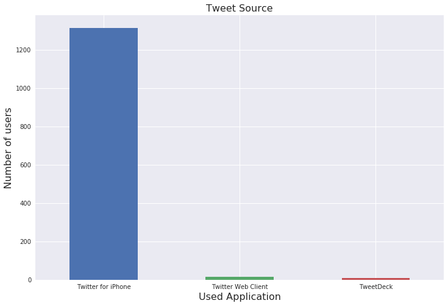

```python
plt.figure(figsize=(12,8))
df_master['source'].value_counts().plot(kind='bar', )
plt.ylabel('Number of users', fontsize=16)
plt.xlabel('Used Application', fontsize=16)
plt.title('Tweet Source', fontsize = 16)
plt.xticks(rotation=0)
#plt.savefig('tweet_source.jpg')
plt.show()
```

**QUESTION :** how do the result of neural net prediction look like?

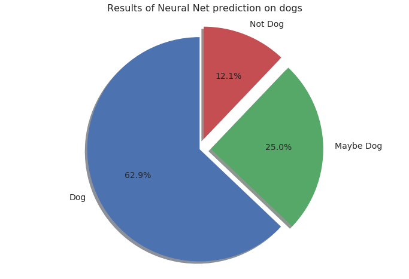

```python
labels = 'Dog', 'Maybe Dog', 'Not Dog',
explode = (0, 0.1, 0.1)

fig1, ax1 = plt.subplots(figsize=(12,8))
ax1.pie(df_master['dog_pred'].value_counts(), explode=explode, labels=labels, autopct='%1.1f%%',
        shadow=True, startangle=90, textprops  = {'fontsize':14})
ax1.axis('equal')
plt.title('Results of Neural Net prediction on dogs', fontsize = 16)
#plt.savefig('nn_pred.jpg')
plt.show()
```

**ANSWER :** the neural net predicted that among all pictures there were 62,9% of pictures of dogs, 12.1% of not dogs ans in 25.0% of cases neural net wasn't sure whether it was dog or not

**QUESTION :** is there any correlation between number of retweets and number of likes?

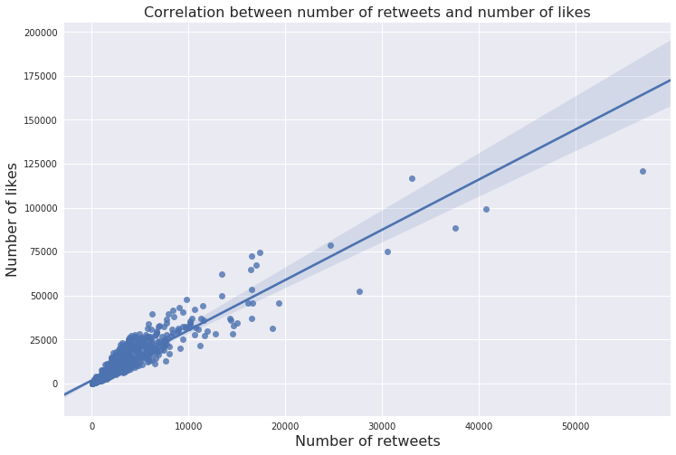

```python
plt.figure(figsize=(12,8))
sns.regplot(df_master['retweet_count'], df_master['favorite_count'])
plt.xlabel('Number of retweets', fontsize=16)
plt.ylabel('Number of likes', fontsize=16)
plt.title('Correlation between number of retweets and number of likes', fontsize=16)
#plt.savefig('correl.jpg')
plt.show()
```

**ANSWER :** according to plot above there is a strong almost linear correlation between number of retweets and likes. The more the dog picture will be retweeted, the more likes it gets

**QUESTION :** how confident was the neural net by predicting the dog on a picture?

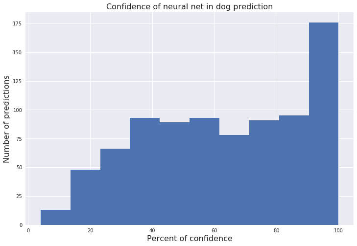

```python
plt.figure(figsize=(12,8))
df_master['prediction1'][df_master['dog_pred'] == 'Dog'].plot(kind='hist')
plt.xlabel('Percent of confidence', fontsize=16)
plt.ylabel('Number of predictions', fontsize=16)
plt.title('Confidence of neural net in dog prediction', fontsize=16)
#plt.savefig('nn_conf.jpg')
plt.show()
```

```python
df_master.head()
```

|  | tweet_id | timestamp | source | rating_numerator | rating_denominator | name | dog_stage | img_num | breed1 | prediction1 | dog_pred | favorite_count | retweet_count |
| --- | --- | --- | --- | --- | --- | --- | --- | --- | --- | --- | --- | --- | --- |
| 0 | 892420643555336193 | 2017-08-01 16:23:56 | Twitter for iPhone | 13 | 10 | Phineas | Unknown | 1 | Orange | 10 | Not Dog | 36291 | 7724 |
| 1 | 892177421306343426 | 2017-08-01 00:17:27 | Twitter for iPhone | 13 | 10 | Tilly | Unknown | 1 | Chihuahua | 32 | Dog | 31298 | 5717 |
| 2 | 891815181378084864 | 2017-07-31 00:18:03 | Twitter for iPhone | 12 | 10 | Archie | Unknown | 1 | Chihuahua | 72 | Dog | 23568 | 3786 |
| 3 | 891689557279858688 | 2017-07-30 15:58:51 | Twitter for iPhone | 13 | 10 | Darla | Unknown | 1 | Paper Towel | 17 | Maybe Dog | 39595 | 7885 |
| 4 | 891327558926688256 | 2017-07-29 16:00:24 | Twitter for iPhone | 12 | 10 | Franklin | Unknown | 2 | Basset | 56 | Dog | 37807 | 8506 |

**QUESTION :** waht are the most popular dog breeds?

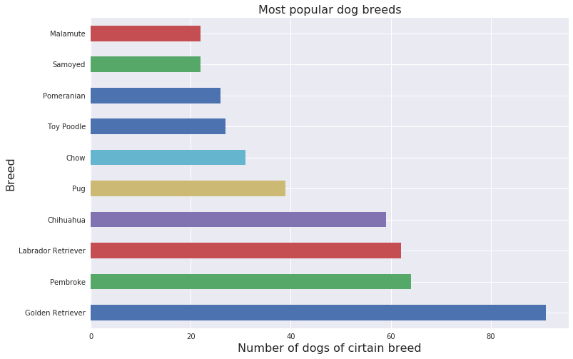

```python
plt.figure(figsize=(12,8))
df_master['breed1'].value_counts()[:10].plot(kind = 'barh')
plt.xlabel('Number of dogs of cirtain breed', fontsize=16)
plt.ylabel('Breed', fontsize=16)
plt.title('Most popular dog breeds', fontsize=16)
#plt.savefig('pop_breeds.jpg')
plt.show()
```

**ANSWER :** three the most popular dog breeds are Golden Retriever, Pembroke and Labrador retriever

**QUESTION :** what are the most popular dogs according to the dog stage rating?

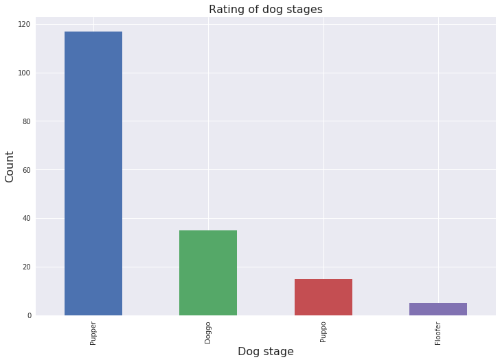

```python
plt.figure(figsize=(12,8))
df_master['dog_stage'].value_counts()[1:].plot(kind = 'bar')
plt.xlabel('Dog stage', fontsize=16)
plt.ylabel('Count', fontsize=16)
plt.title('Rating of dog stages', fontsize=16)
#plt.savefig('stage_rating.jpg')
plt.show()
```

**ANSWER :** the rating of dog stages beginns with pupper, doggo, puppo and ends with floofer